Análisis de Datos y Machine Learning con R (Utilizando la librería Caret)

Grupo: DIN-A4

Integrante 1: Daniel Aliaga Sánchez - daniel.a.s@um.es  
Integrante 2: Javier Guardiola González - j.guardiolagonzalez@um.es  
Integrante 3: Mercedes López Caballero - m.lopezcaballero@um.es  
Integrante 4: Samuel Muñoz Burillo - s.munozburillo@um.es

29/06/2026

# Introducción

Este documento corresponde a la práctica final de la asignatura Aprendizaje Computacional. Incluye el proceso relacionado con el análisis de datos y posterior procedimiento de Machine Learning aplicado a los datos correspondientes un dataset de concesión de créditos.

El objetivo de la práctica ha sido el de entrenar y evaluar ciertos modelos para poder obtener predicciones lo más fieles a la realidad posible. Para ello, hemos seleccionado 4 modelos diferentes, todos ellos entrenados según 3 datasets procesados de manera distinta para así poder llegar a la solución que mejor resultados nos proporcione. Estos 4 modelos son: Support Vector Machines (SVM), Random Forest (RF), Redes Neuronales Artificiales (ANN) y Análisis Discriminante Lineal (LDA). Después de su entrenamiento, procederemos a compararlos de dos modos: primero los propios modelos con sus 3 datasets distintos, y luego entre todos ellos, cogiendo el mejor dataset de cada uno por separado y comparando los 4 resultados finales.

Para poder llevar a cabo todo este proceso, comenzaremos con un análisis exploratorio de los datos seguido de su preprocesado de manera básica para poder tener los datos listos para el entrenamiento. Destacaremos varias variables haciendo un análisis más detallado de las mismas, y por último nos centraremos más de lleno en los propios datos de train. Cabe mencionar aquí que, los datos que recibimos, se pueden separar entre train (entrenamiento) y test (pruebas), de modo que usaremos los primeros para entrenar a los modelos y los últimos para realizar las pruebas correspondientes. En caso contrario, no podríamos asegurar que los resultados son consistentes, pues estaríamos entrenando y comprobando con los mismos datos.

# Sección 1: Análisis Exploratorio de Datos y preproceso básico de datos

## Carga de librerías

Para poder llevar a cabo cada uno de los procedimientos necesarios para tanto el análisis como el entrenamiento de modelos, vamos a precisar de ciertas librerías. Por ello, vamos a importarlas en este apartado para que, así, estén presentes a lo largo de todo el documento.

```r
library(ggplot2)
library(caret)
library(corrplot)
library(psych)
library(dplyr)
library(RANN)
library(gridExtra)
library(lattice)
library(fastDummies)
library(MASS)
library(tidyr)
```

## Carga de datos

Importamos los datos del dataset y modificamos los nombres referentes a las columnas teniendo en cuenta la información contenida tanto en el fichero crx.names como en la web de la uci proporcionada (https://archive.ics.uci.edu/dataset/27/credit+approval). Para el preprocesamiento vamos a trabajar con una copia del dataset para no modificar los datos del original (original - credit / copia - ccredit):

```r
credit <- read.table("credit+approval/crx.data", sep = ",", header = FALSE, na.strings = "?")
ccredit <- credit
colnames(ccredit) <- c("A1", "A2", "A3", "A4", "A5", "A6", "A7", "A8","A9", "A10", "A11", "A12", "A13", "A14", "A15", "A16")
```

Vamos a ver ahora el tipo de dato de cada una de las variables, las cuales clasificaremos en numéricas y categóricas:

```r
str(ccredit)
```

```
## 'data.frame':    690 obs. of  16 variables:
##  $ A1 : chr  "b" "a" "a" "b" ...
##  $ A2 : num  30.8 58.7 24.5 27.8 20.2 ...
##  $ A3 : num  0 4.46 0.5 1.54 5.62 ...
##  $ A4 : chr  "u" "u" "u" "u" ...
##  $ A5 : chr  "g" "g" "g" "g" ...
##  $ A6 : chr  "w" "q" "q" "w" ...
##  $ A7 : chr  "v" "h" "h" "v" ...
##  $ A8 : num  1.25 3.04 1.5 3.75 1.71 ...
##  $ A9 : chr  "t" "t" "t" "t" ...
##  $ A10: chr  "t" "t" "f" "t" ...
##  $ A11: int  1 6 0 5 0 0 0 0 0 0 ...
##  $ A12: chr  "f" "f" "f" "t" ...
##  $ A13: chr  "g" "g" "g" "g" ...
##  $ A14: int  202 43 280 100 120 360 164 80 180 52 ...
##  $ A15: int  0 560 824 3 0 0 31285 1349 314 1442 ...
##  $ A16: chr  "+" "+" "+" "+" ...
```

```r
c_categoricos <- paste0("A", c(1,4:7,9,10,12,13,16))
c_numericos <- paste0("A", c(2,3,8,11,14,15))

ccredit[c_categoricos] = data.frame(lapply(ccredit[c_categoricos], FUN=as.factor))
ccredit[c_numericos] = data.frame(lapply(ccredit[c_numericos], FUN=as.numeric))
```

Como observamos en el dataset, tenemos 690 observaciones y 16 variables, de las cuales 15 son predictores (A1:A15) y una, objetivo (A16).

Como podemos ver, las variables A1, A4, A5, A6, A7, A9, A10, A12, A13 y A16 tienen como tipo “char”, por lo que las clasificaremos como “Categóricas”, mientras que el resto, A2, A3, A8, A11, A14 y A15, son numéricas, tipo num e int. Además, hemos convertido los 10 discretos a factores, incluyendo el objetivo, dado que esto ayuda a que la librería Caret pueda distinguir entre problemas de regresión y problemas de clasificación, siendo el nuestro de este último. También transformamos los int y num a numérico para obtener mayor precisión y flexibilidad.

Para preparar los datos para tener un mejor análisis, vamos a hacer una copia de ccredit para trabajar en un conjunto sin datos desconocidos o nulos, es decir, sin NAs. No vamos a eliminarlos, simplemente los obviamos por el momento, pudiendo tratarlos más adelante.

Como al importar la base de datos hemos indicado que “na.strings =”?” “, no tenemos que comprobar si hay alguna variable que obtenga el valor”?“, puesto que esto le dice a R que cualquier”?” se convierta automáticamente en NA. Por ello, simplemente tratamos los valores de NA.

```r
sinNA<- na.omit(ccredit)
colnames(sinNA) <- c("A1","A2","A3","A4","A5","A6","A7","A8","A9","A10","A11","A12","A13","A14","A15","A16")
str(sinNA)
```

```
## 'data.frame':    653 obs. of  16 variables:
##  $ A1 : Factor w/ 2 levels "a","b": 2 1 1 2 2 2 2 1 2 2 ...
##  $ A2 : num  30.8 58.7 24.5 27.8 20.2 ...
##  $ A3 : num  0 4.46 0.5 1.54 5.62 ...
##  $ A4 : Factor w/ 3 levels "l","u","y": 2 2 2 2 2 2 2 2 3 3 ...
##  $ A5 : Factor w/ 3 levels "g","gg","p": 1 1 1 1 1 1 1 1 3 3 ...
##  $ A6 : Factor w/ 14 levels "aa","c","cc",..: 13 11 11 13 13 10 12 3 9 13 ...
##  $ A7 : Factor w/ 9 levels "bb","dd","ff",..: 8 4 4 8 8 8 4 8 4 8 ...
##  $ A8 : num  1.25 3.04 1.5 3.75 1.71 ...
##  $ A9 : Factor w/ 2 levels "f","t": 2 2 2 2 2 2 2 2 2 2 ...
##  $ A10: Factor w/ 2 levels "f","t": 2 2 1 2 1 1 1 1 1 1 ...
##  $ A11: num  1 6 0 5 0 0 0 0 0 0 ...
##  $ A12: Factor w/ 2 levels "f","t": 1 1 1 2 1 2 2 1 1 2 ...
##  $ A13: Factor w/ 3 levels "g","p","s": 1 1 1 1 3 1 1 1 1 1 ...
##  $ A14: num  202 43 280 100 120 360 164 80 180 52 ...
##  $ A15: num  0 560 824 3 0 ...
##  $ A16: Factor w/ 2 levels "-","+": 2 2 2 2 2 2 2 2 2 2 ...
##  - attr(*, "na.action")= 'omit' Named int [1:37] 72 84 87 93 98 203 207 244 249 255 ...
##   ..- attr(*, "names")= chr [1:37] "72" "84" "87" "93" ...
```

```r
colSums(is.na(sinNA))
```

```
##  A1  A2  A3  A4  A5  A6  A7  A8  A9 A10 A11 A12 A13 A14 A15 A16
##   0   0   0   0   0   0   0   0   0   0   0   0   0   0   0   0
```

Para ver un poco cómo vamos y cómo van quedando los datos, vamos a hacer un resumen de cada una de las variables. Empezamos por las categóricas:

```r
summary(sinNA$A1)
```

```
##   a   b
## 203 450
```

```r
summary(sinNA$A4)
```

```
##   l   u   y
##   2 499 152
```

```r
summary(sinNA$A5)
```

```
##   g  gg   p
## 499   2 152
```

```r
summary(sinNA$A6)
```

```
##  aa   c  cc   d   e  ff   i   j   k   m   q   r   w   x
##  52 133  40  26  24  50  55  10  48  38  75   3  63  36
```

```r
summary(sinNA$A7)
```

```
##  bb  dd  ff   h   j   n   o   v   z
##  53   6  54 137   8   4   2 381   8
```

```r
summary(sinNA$A9)
```

```
##   f   t
## 304 349
```

```r
summary(sinNA$A10)
```

```
##   f   t
## 366 287
```

```r
summary(sinNA$A12)
```

```
##   f   t
## 351 302
```

```r
summary(sinNA$A13)
```

```
##   g   p   s
## 598   2  53
```

```r
summary(sinNA$A16)
```

```
##   -   +
## 357 296
```

Analizando las categóricas, si comparamos con lo que se nos proporciona en la web de la uci, vemos que hay alguna variable que no tiene todos sus valores. Si nos fijamos en el apartado de “Additional Variable Information”, los valores de cada una son los siguientes:

```
A1: b, a.
A4: u, y, l, t.
A5: g, p, gg.
A6: c, d, cc, i, j, k, m, r, q, w, x, e, aa, ff.
A7: v, h, bb, j, n, z, dd, ff, o.
A9: t, f.
A10: t, f.
A12: t, f.
A13: g, p, s.
A16: +,- (class attribute)
```

Comparando con el nuestro, podemos ver que la variable A4, en este dataset sólo contiene valores l, u, y, pero no tiene t. Por ello, vamos a incluir este nivel en nuestro conjunto de datos.

```r
ccredit$A4 <- factor(ccredit$A4, levels = c("u", "y", "l", "t"))
sinNA$A4 <- factor(sinNA$A4, levels = c("u", "y", "l", "t"))
```

Como ya habíamos hecho la copia extra sin valores NA, tenemos que añadir en ella también el nivel. Al añadir el nivel “t” a A4, se incluyen todas las categorías posibles sin cambiar los datos existentes. Por ello, no es necesario comprobar NA, ya que la adición de un nivel vacío no genera valores faltantes.

Continuando con las numéricas, vamos a ver el “resumen” de una forma diferente, puesto que las categóricas toman valores concretos (niveles), algo que no sucede con estas variables.

```r
summary(sinNA$A2)
```

```
##    Min. 1st Qu.  Median    Mean 3rd Qu.    Max.
##   13.75   22.58   28.42   31.50   38.25   76.75
```

```r
summary(sinNA$A3)
```

```
##    Min. 1st Qu.  Median    Mean 3rd Qu.    Max.
##   0.000   1.040   2.835   4.830   7.500  28.000
```

```r
summary(sinNA$A8)
```

```
##    Min. 1st Qu.  Median    Mean 3rd Qu.    Max.
##   0.000   0.165   1.000   2.244   2.625  28.500
```

```r
summary(sinNA$A11)
```

```
##    Min. 1st Qu.  Median    Mean 3rd Qu.    Max.
##   0.000   0.000   0.000   2.502   3.000  67.000
```

```r
summary(sinNA$A14)
```

```
##    Min. 1st Qu.  Median    Mean 3rd Qu.    Max.
##     0.0    73.0   160.0   180.4   272.0  2000.0
```

```r
summary(sinNA$A15)
```

```
##    Min. 1st Qu.  Median    Mean 3rd Qu.    Max.
##       0       0       5    1014     400  100000
```

## Análisis Monovariable

Vamos a realizar el análisis monovariable de las variables A2, A6 y A15. Seleccionamos las variables A2, A6 y A15 por ser representativas:

- A2, por ser numérica con sesgo claro
- A6, categórica con alta variabilidad de niveles
- A15, numérica con outliers extremos

### A.M.: Variable A2

```r
summary(sinNA$A2)
```

```
##    Min. 1st Qu.  Median    Mean 3rd Qu.    Max.
##   13.75   22.58   28.42   31.50   38.25   76.75
```

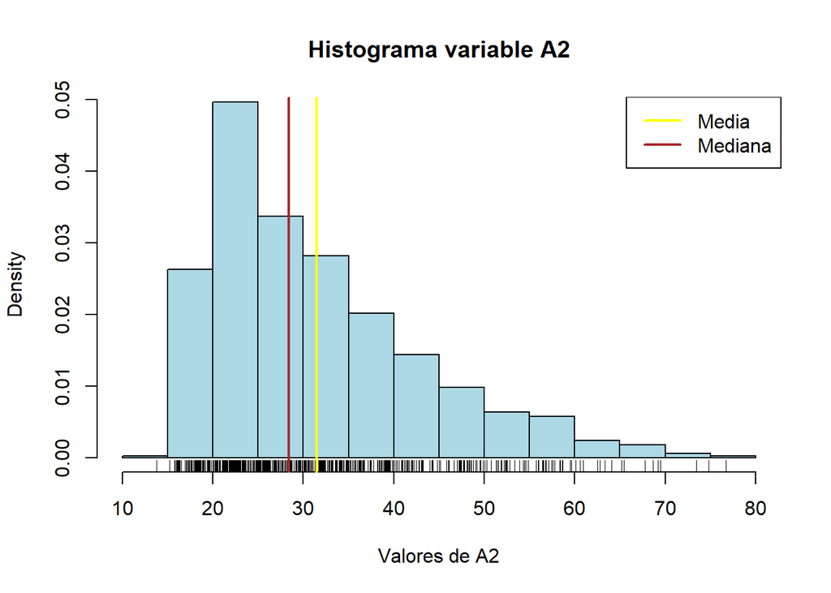

```r
dens_A2 <- density(sinNA$A2, na.rm = TRUE)
hist(sinNA$A2, xlab = "Valores de A2",
     main = "Histograma variable A2",
     ylim = c(0, max(dens_A2$y) * 1.1), probability = TRUE,
     col = "lightblue")
rug(jitter(sinNA$A2))

abline(v = mean(sinNA$A2, na.rm = TRUE), col = "yellow", lwd = 2)
abline(v = median(sinNA$A2, na.rm = TRUE), col = "brown", lwd = 2)
legend("topright", legend = c("Media", "Mediana"), col = c("yellow", "brown"), lwd = 2)
```

Viendo las cotas superiores e inferiores y la manera en la que estan distribuidos los valores, como hemos comentado, se sospecha que esta columna representa la edad. Si ejecutamos su diagrama caja-bigotes, podremos ver realmente cómo se distribuyen los valores y si hay algún extremo o outlier, ya que, según el summary ejecutado previamente, desde el tercer cuartil (38.25) hasta el valor máximo (76.75) hay bastante diferencia, lo que podría indicar la presencia de estos:

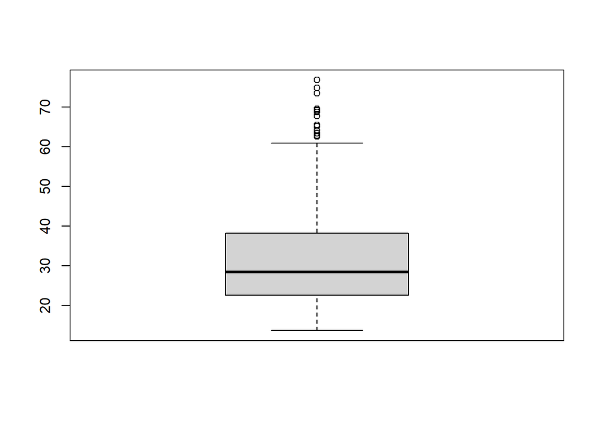

```r
boxplot(sinNA[2],names = c("A2"))
```

Teniendo en cuenta el diagrama resultado, vemos cómo se podría reforzar nuestra idea de que sean edades. Vemos cómo los valores se distribuyen entre 20 y 30, y que a partir de 60 se consideran que los datos son outliers.

Vamos a ver cómo se comporta respecto a la clase (variable A16):

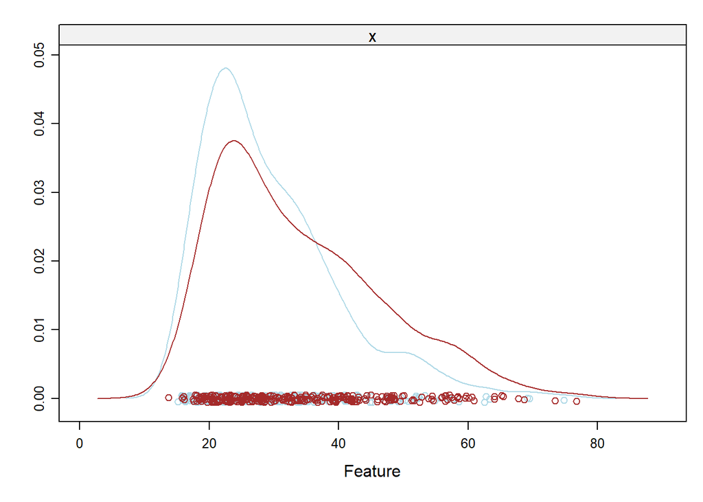

```r
escalas <- list(x=list(relation="free"), y=list(relation="free"))
featurePlot(x=sinNA[,"A2"], y=as.factor(sinNA[,"A16"]), plot="density", scales=escalas, col =  c("lightblue", "brown"))
```

Se aprecia como se rechazan la gran mayoria de los créditos entre valores de 20 y 40, lo cual cuadraría con la hipótesis de que esta columna representa la edad.

Si ejecutamos el QQ-plot para evaluar la normalidad,podemos ver si la variable se aleja de la normalidad, lo que puede explicar el sesgo que veíamos en el histograma:

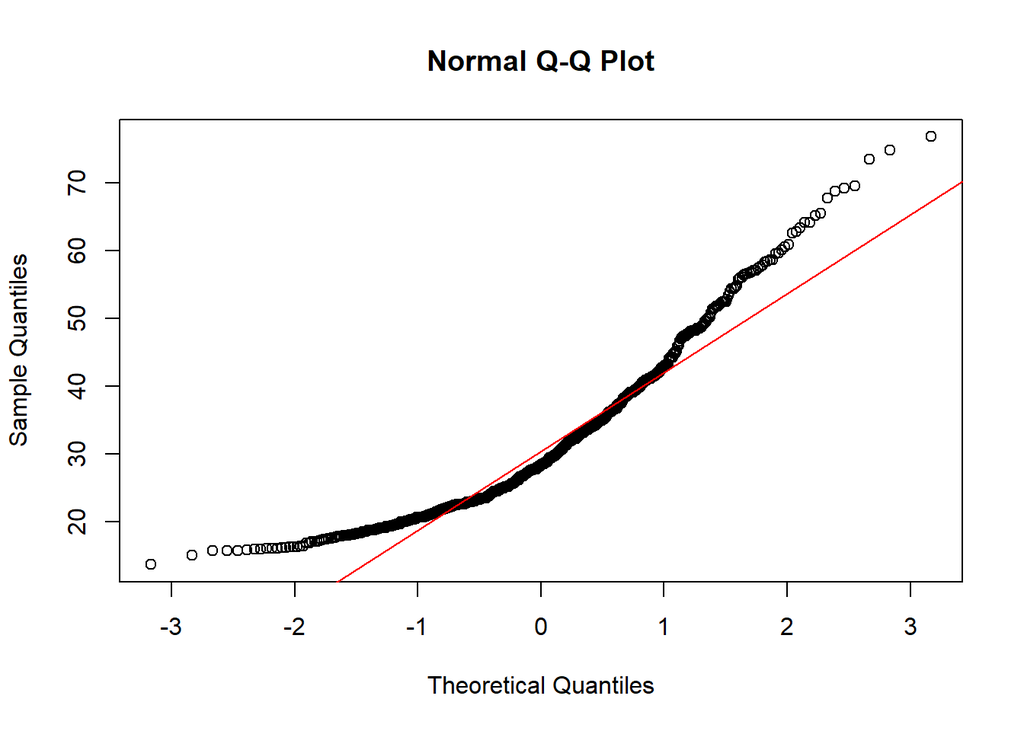

```r
qqnorm(sinNA$A2)
qqline(sinNA$A2, col="red")
```

Además, podemos ver el Violin plot para ver cómo se comporta con respecto a la clase A16. Este combina el boxplot y la densidad para ver cómo se distribuye A2 según se concede o no el crédito. Permite visualizar de forma clara si la edad (A2) se comporta distinto según se concede el crédito o no:

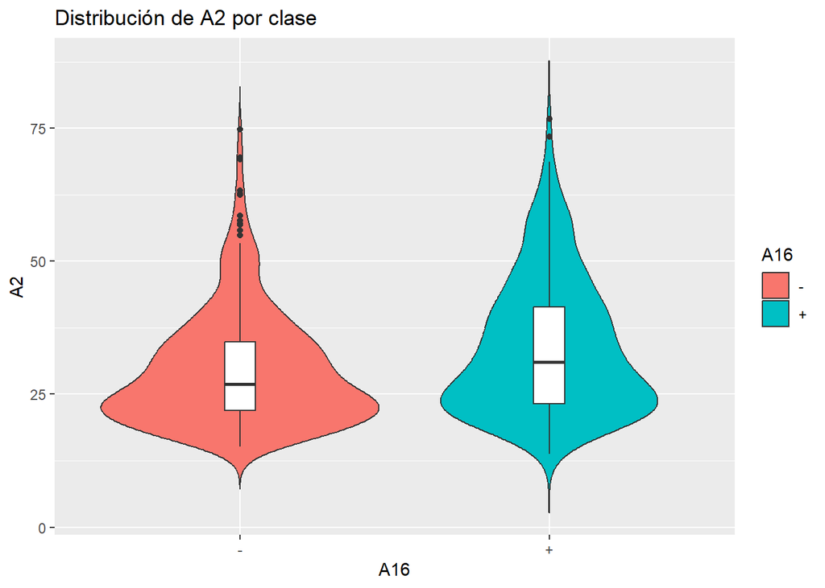

```r
ggplot(sinNA, aes(x=A16, y=A2, fill=A16)) +
geom_violin(trim=FALSE) +
geom_boxplot(width=0.1, fill="white") +
labs(title="Distribución de A2 por clase")
```

### A.M.: Variable A6:

```r
length(levels(sinNA$A6))
```

```
## [1] 14
```

Vemos que hay 14 valores distintos, nos centramos ahora en su distribución.

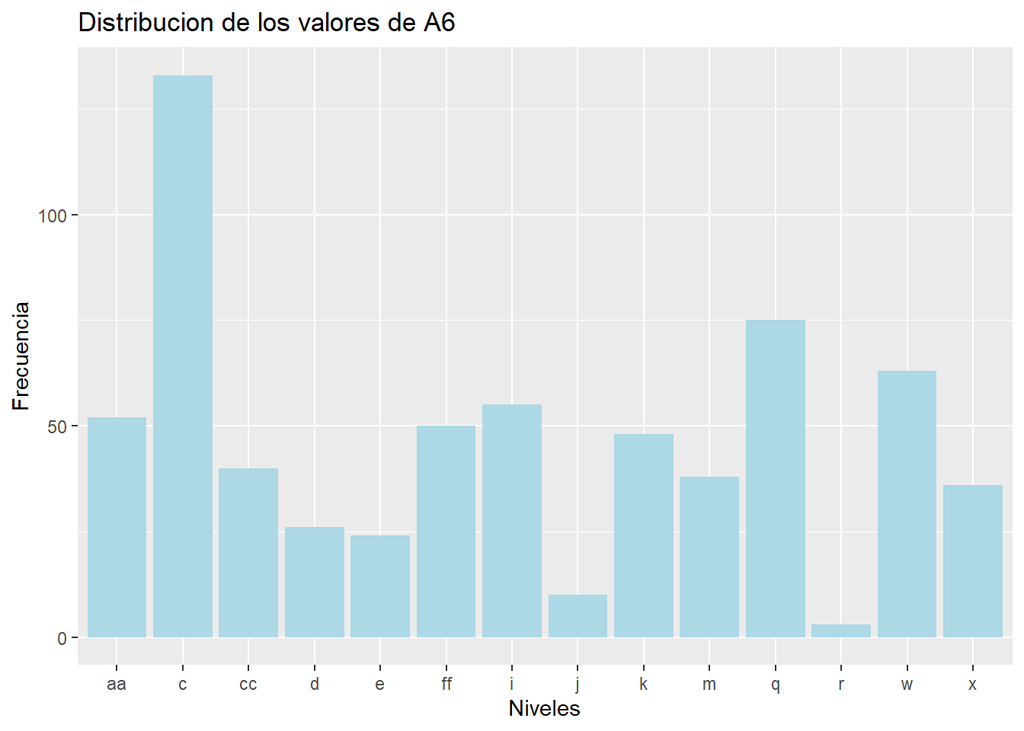

```r
ggplot(sinNA, aes(x=A6)) +
  geom_bar(fill="lightblue") +
  labs(title="Distribucion de los valores de A6", x="Niveles", y="Frecuencia")
```

Observamos una gran diferencias entre las ocurrencias de “c” con respecto a los demás valores, con pocas ocurrencias de “j” y “r”.

Ahora podemos ver, mediante la siguiente gráfica, cuánto se concede el crédito en función de cada valor de A6, es decir, comparar esta con la A16:

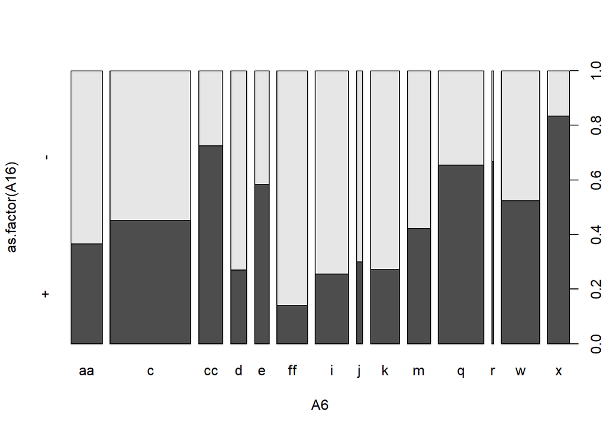

```r
spineplot(as.factor(A16) ~ A6 , sinNA)
```

Para continuar con el análisis, hemos decidido elaborar un diagrama caja-bigotes (box & whiskers) principalmente para ver los outliers de la variable.

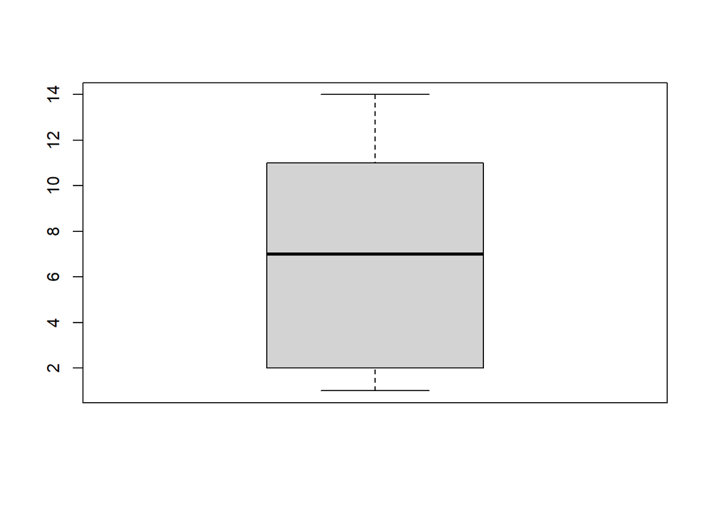

```r
boxplot(sinNA[6],names = c("A6"))
```

Como podemos observar, esta variable no tiene outliers significativos, por lo que no tenemos que preocuparnos por ello.

De la misma manera que en la anterior, vamos a ejecutar el QQ-plot para ver la distribución aproximada:

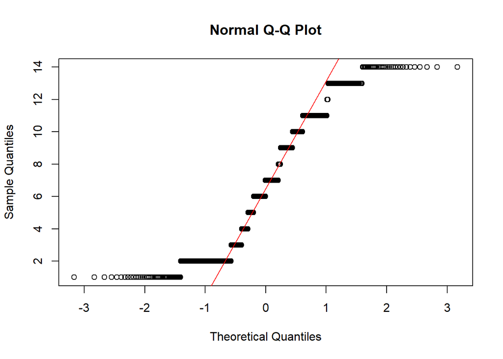

```r
qqnorm(as.numeric(as.factor(sinNA$A6)))
qqline(as.numeric(as.factor(sinNA$A6)), col="red")
```

En el QQ-plot, las barras negras se alinean consistentemente, salvo alguna excepción, sobre la línea roja, lo que indica que la distribución de los niveles de A6 (convertidos a valores numéricos) sigue de manera aproximada un patrón uniforme o “regular”, sin sesgo fuerte.

### A.M.: Variable A15:

Siguiendo con el mismo proceso que hemos llevado a cabo en la variable anterior, vamos ahora a analizar la variable A15.

```r
summary(sinNA$A15)
```

```
##    Min. 1st Qu.  Median    Mean 3rd Qu.    Max.
##       0       0       5    1014     400  100000
```

En este caso y como en A2, al ser A15 una variable numérica, vemos su summary. Vemos que es interesante analizarla puesto que la media y la mediana son muy diferentes (1014 contra 5)

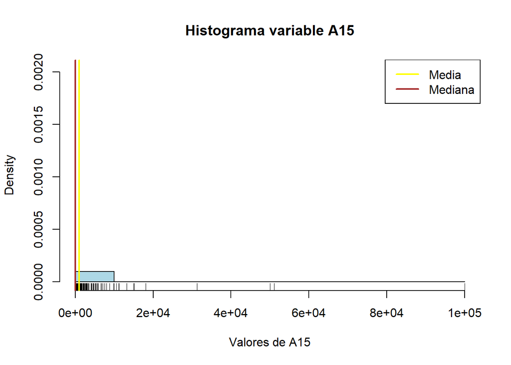

```r
dens_A15 <- density(sinNA$A15, na.rm = TRUE)
hist(sinNA$A15, xlab = "Valores de A15",
     main = "Histograma variable A15",
     ylim = c(0, max(dens_A15$y) * 1.1), probability = TRUE,
     col = "lightblue")
rug(jitter(sinNA$A15))

abline(v = mean(sinNA$A15, na.rm = TRUE), col = "yellow", lwd = 2)
abline(v = median(sinNA$A15, na.rm = TRUE), col = "brown", lwd = 2)
legend("topright", legend = c("Media", "Mediana"), col = c("yellow", "brown"), lwd = 2)
```

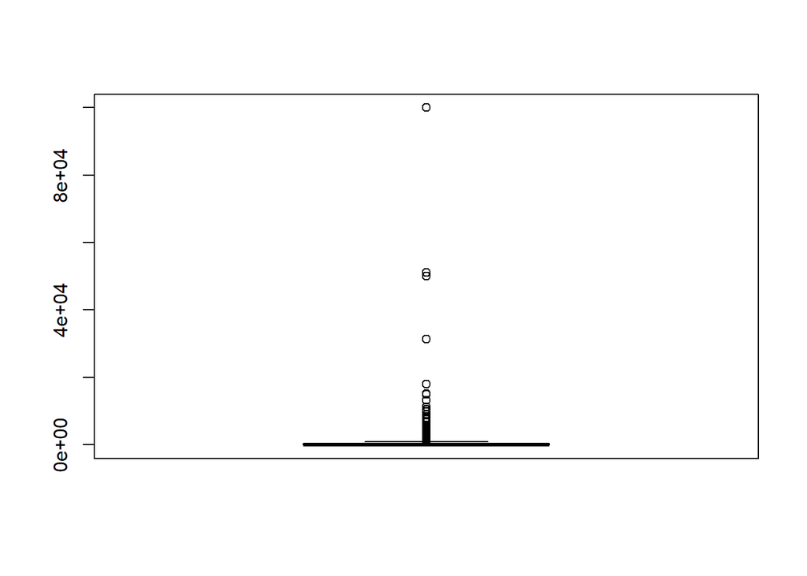

```r
boxplot(sinNA[15],names = c("A15"))
```

Como podemos observar, los outliers son bastante dispares, lo que hace que la “caja” del diagrama casi no se vea en la representación. Para ello, y de manera ilustrativa, vamos a analizar de forma temporal la variable sin los outliers, es decir, vamos a “recortarla” para quedarnos sólo con lo más representativo:

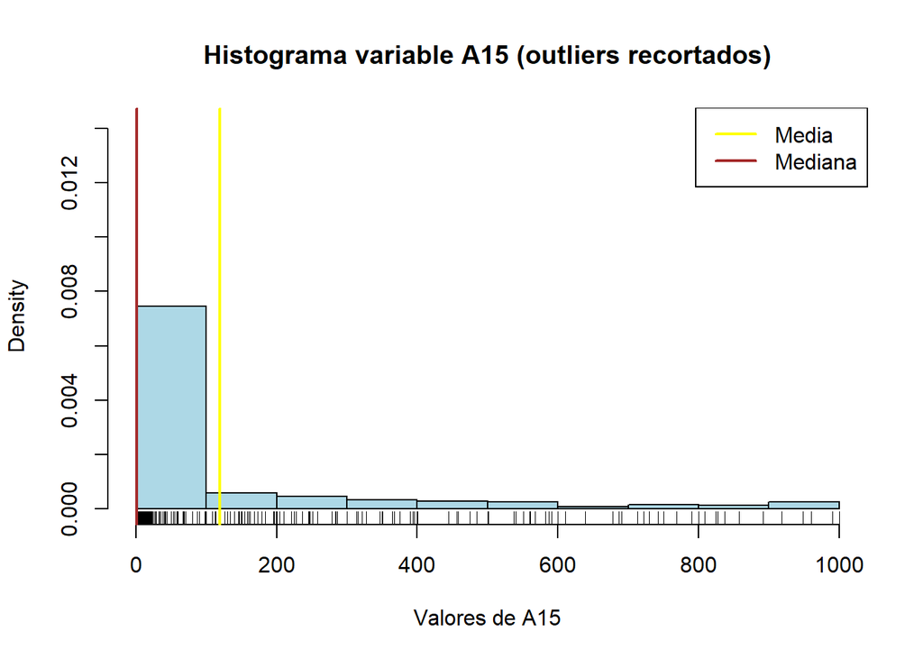

```r
Q1 <- quantile(sinNA$A15, 0.25, na.rm = TRUE)
Q3 <- quantile(sinNA$A15, 0.75, na.rm = TRUE)
IQR_val <- Q3 - Q1
max_lim <- Q3 + 1.5 * IQR_val
A15_recortada <- sinNA$A15[sinNA$A15 <= max_lim]

dens_A15 <- density(A15_recortada, na.rm = TRUE)

# Histograma
hist(A15_recortada,
     xlab = "Valores de A15",
     main = "Histograma variable A15 (outliers recortados)",
     ylim = c(0, max(dens_A15$y) * 1.1),
     probability = TRUE,
     col = "lightblue")
rug(jitter(A15_recortada))
abline(v = mean(A15_recortada, na.rm = TRUE), col = "yellow", lwd = 2)
abline(v = median(A15_recortada, na.rm = TRUE), col = "brown", lwd = 2)
legend("topright", legend = c("Media", "Mediana"), col = c("yellow", "brown"), lwd = 2)
```

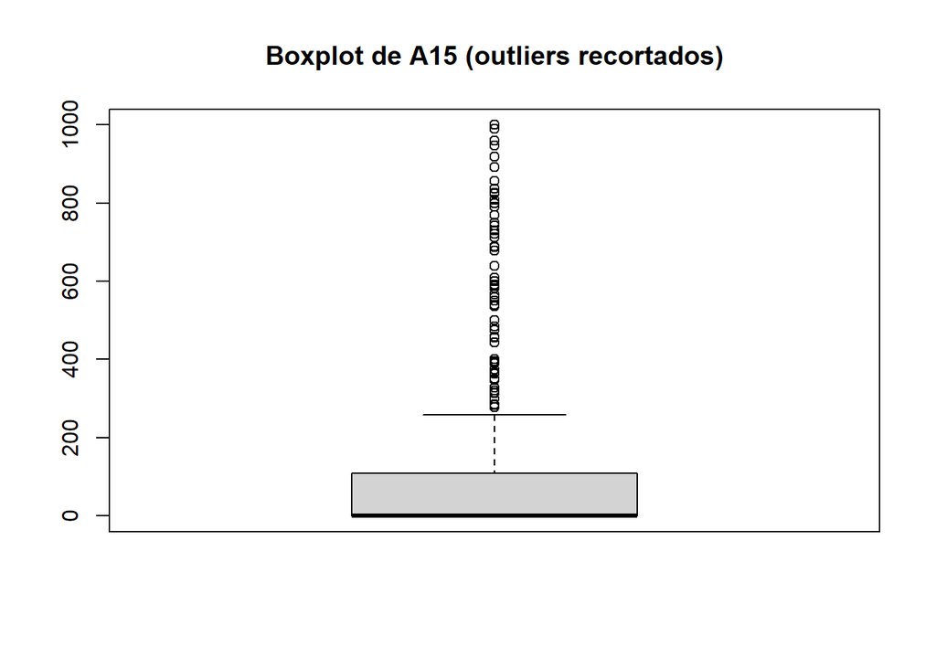

```r
Q1 <- quantile(sinNA$A15, 0.25, na.rm = TRUE)
Q3 <- quantile(sinNA$A15, 0.75, na.rm = TRUE)
IQR_val <- Q3 - Q1
max_lim <- Q3 + 1.5 * IQR_val

A15_recortada <- sinNA$A15[sinNA$A15 <= max_lim]

boxplot(A15_recortada, names = c("A15"),
        main = "Boxplot de A15 (outliers recortados)")
```

Como podemos observar en cualquiera de los dos gráficos, los datos más representativos de la variable A15 se encuentran del 0 al 100.

Con el QQ-plot podemos ver la aproximación a normalidad

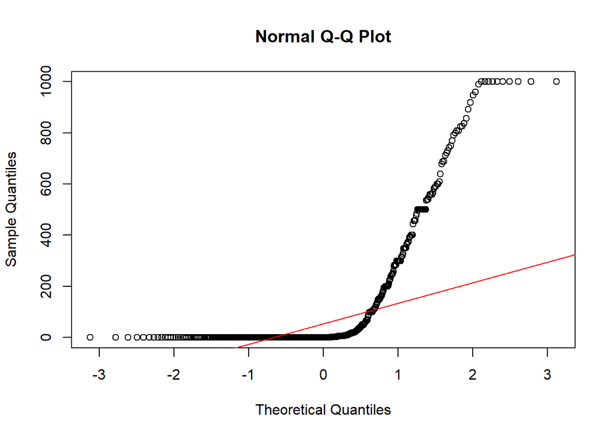

```r
qqnorm(A15_recortada)
qqline(A15_recortada, col="red")
```

Los puntos están muy lejos de la línea roja, acercándose a ella tan solo en el rango (-1,1), lo que indica una fuerte desviación de la normalidad.

La dispersión tan alta de los puntos extremos, tanto en este como en el boxplot, refleja outliers muy marcados, consistentes con los valores altos que vimos en el histograma.

Veamos ahora cómo se comporta en relación a A16:

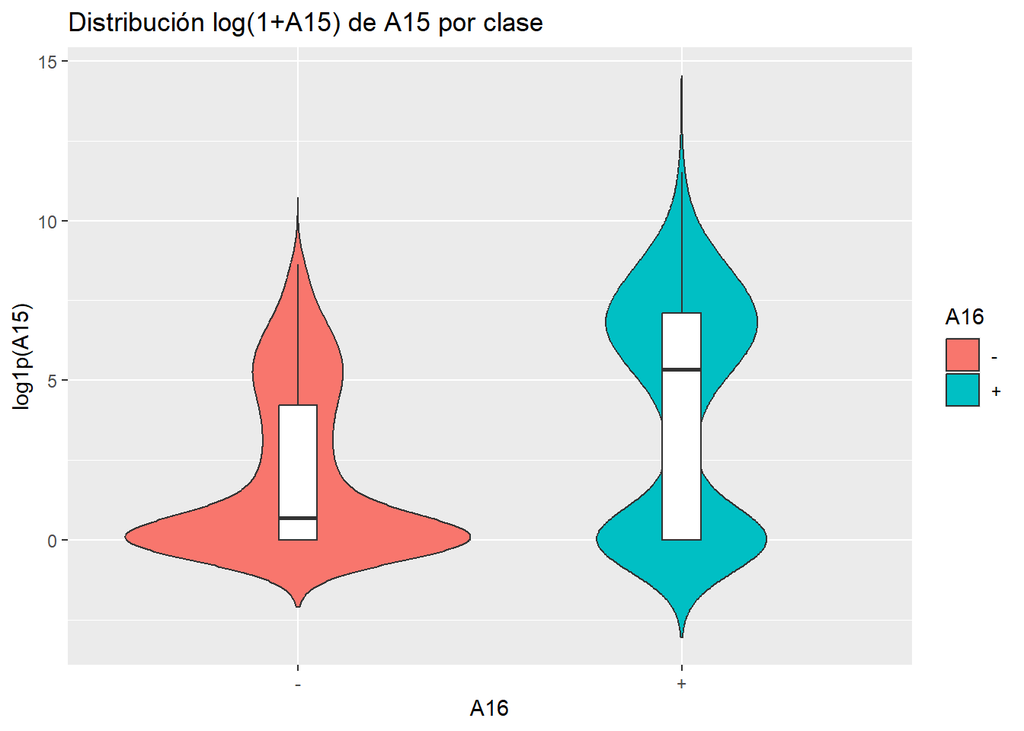

```r
ggplot(sinNA, aes(x=A16, y=log1p(A15), fill=A16)) +
  geom_violin(trim=FALSE) +
  geom_boxplot(width=0.1, fill="white") +
  labs(title="Distribución log(1+A15) de A15 por clase")
```

Cabe destacar que hemos aplicado la transformación logarítmica log1p(A15) para ver el Violin Plot con el objetivo de reducir la influencia de valores extremos y mejorar la visualización de su distribución.

## Análisis Multivariable

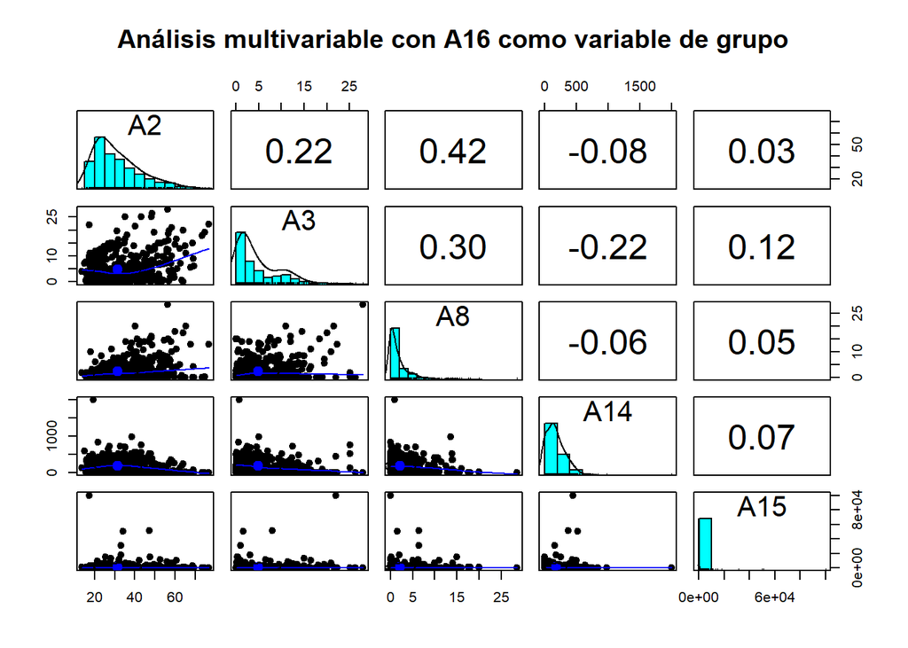

```r
suppressWarnings(
  pairs.panels(
    sinNA[, c("A2", "A3", "A8", "A14", "A15")],
    group = sinNA$A16,
    pch = 19,
    main = "Análisis multivariable con A16 como variable de grupo"
  )
)
```

En conjunto, las variables más prometedoras para el modelado parecen ser A2, A3 y A8, mientras que A14 y A15 requerirán transformaciones para corregir el sesgo y la amplia dispersión observada.

Cabe destacar que usamos suppressWarnings() porque la función pairs.panels() genera avisos internos irrelevantes, relacionados con parámetros gráficos que no afectan al resultado. El gráfico se dibuja correctamente, así que simplemente ocultamos esos warnings para evitar ruido y mantener la salida limpia.

## Tratamiento de outliers

Vamos a buscar las variables que tengan mayor porcentaje de valores átipicos (outliers).

### A2

Comenzamos por la variable A2 que, como vimos en el apartado de análisis monovariable, tiene un porcentaje bajo de valores atípicos.

```r
a2 <- (sinNA$A2)
statsA2 <- boxplot.stats(a2)
atipicA2 <- statsA2$out
porcentajeA2 <- 100 * length(atipicA2) / length(a2)

print(paste("El porcentaje de datos atípicos para A2 es =", porcentajeA2))
```

```
## [1] "El porcentaje de datos atípicos para A2 es = 2.14395099540582"
```

Como hemos comentado, esta variable ya ha sido analizada en profundidad con el análisis monovariable. Es por ello que hemos decidido no volver a incluir representaciones como histogramas o diagramas, para evitar la repetición y la redundancia. En oposición a esta, el resto de variables que no han sido tratadas con anterioridad, sí contendrán un desarrollo un poco mayor. Este análisis inlcuye tanto el histograma como el diagrama caja-bigotes, para así poder ver los posibles outliers de la misma manera que en las representadas en el análisis monovariable.

### A3:

```r
a3 <- (sinNA$A3)
statsA3 <- boxplot.stats(a3)
atipicA3 <- statsA3$out
porcentajeA3 <- 100 * length(atipicA3) / length(a3)

print(paste("El porcentaje de datos atípicos para A3 es =", porcentajeA3))
```

```
## [1] "El porcentaje de datos atípicos para A3 es = 2.60336906584992"
```

Según esto, el porcentaje de datos atípicos de la variable A3 es, de la misma manera que en A2, bastante bajo. Procedemos ahora a verlo de forma gráfica mediante el histograma.

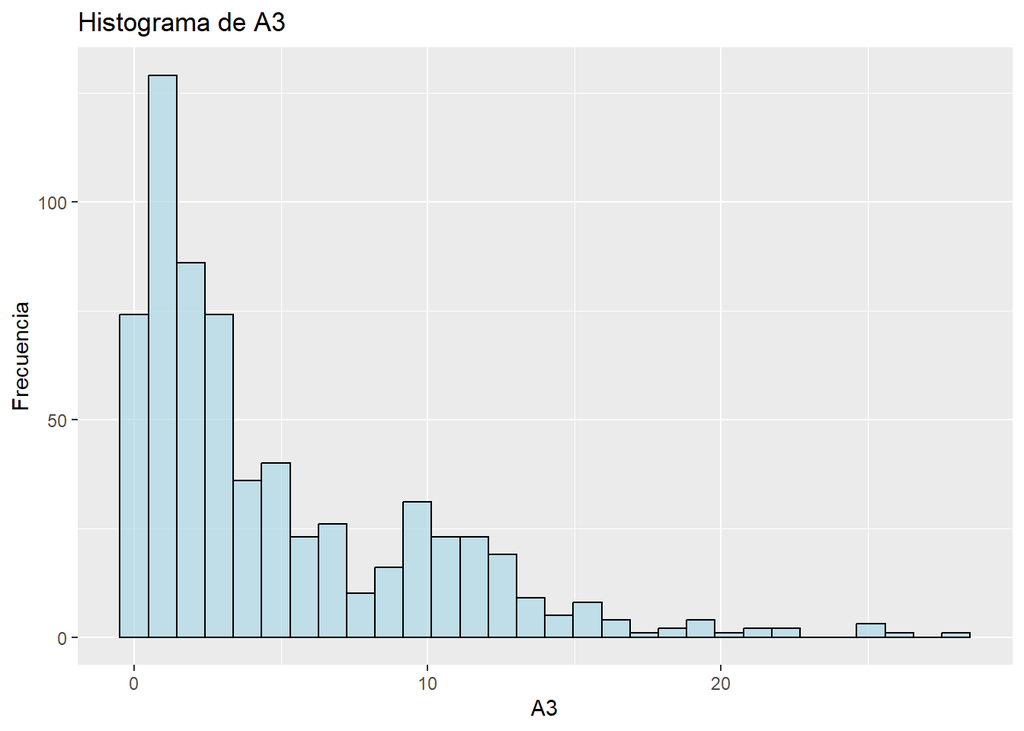

```r
ggplot(sinNA, aes(x = A3)) +
  geom_histogram(bins = 30, fill = "lightblue", color = "black", alpha = 0.7) +
  labs(title = "Histograma de A3", x = "A3", y = "Frecuencia")
```

Al observar el histograma se aprecia que la variable presenta una distribución asimétrica hacia la derecha, con una cola prolongada. No obstante, dado que el porcentaje de valores atípicos detectado es reducido, estos casos no distorsionan de forma significativa la distribución. Para confirmarlo, procedemos a elaborar el diagrama de bigotes.

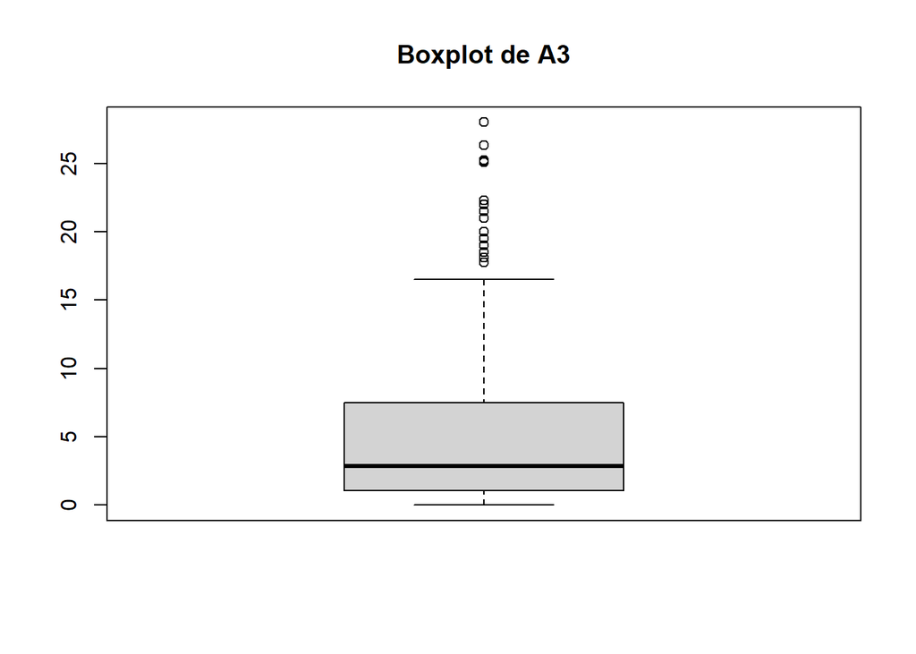

```r
boxplot(sinNA[3],names = c("A3"),main="Boxplot de A3")
```

Con este diagrama confirmamos lo mencionado con anterioridad ya que vemos que no hay una gran cantidad de valores fuera de rango.

### A8:

```r
a8 <- (sinNA$A8)
statsA8 <- boxplot.stats(a8)
atipicA8 <- statsA8$out
porcentajeA8 <- 100 * length(atipicA8) / length(a8)

print(paste("El porcentaje de datos atípicos para A8 es =", porcentajeA8))
```

```
## [1] "El porcentaje de datos atípicos para A8 es = 9.03522205206738"
```

Comparando con las variables anteriores, ahora tenemos un número considerable de outliers, puesto que casi 1 de cada 10 valores es atípico (9% de los datos).

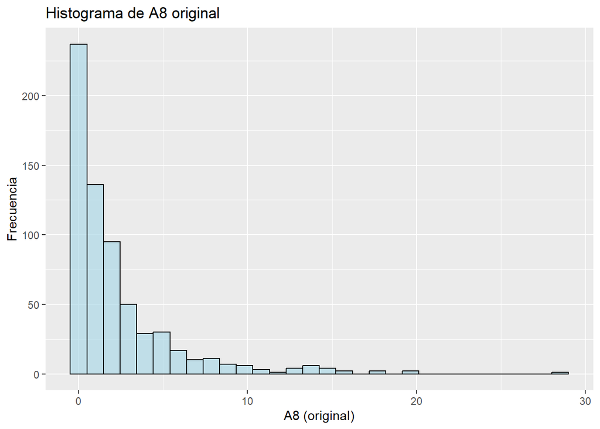

```r
ggplot(sinNA, aes(x = A8)) +
  geom_histogram(bins = 30, fill = "lightblue", color = "black", alpha = 0.7) +
  labs(title = "Histograma de A8 original", x = "A8 (original)", y = "Frecuencia")
```

Viendo el histograma comprobamos que la variable A8 tiene la mayoría de sus valores agrupados entre 0 y 10, por lo que, los que no están en ese grupo de valores, se puede decir que son outliers.

Ahora vamos a analizar su diagrama caja bigotes:

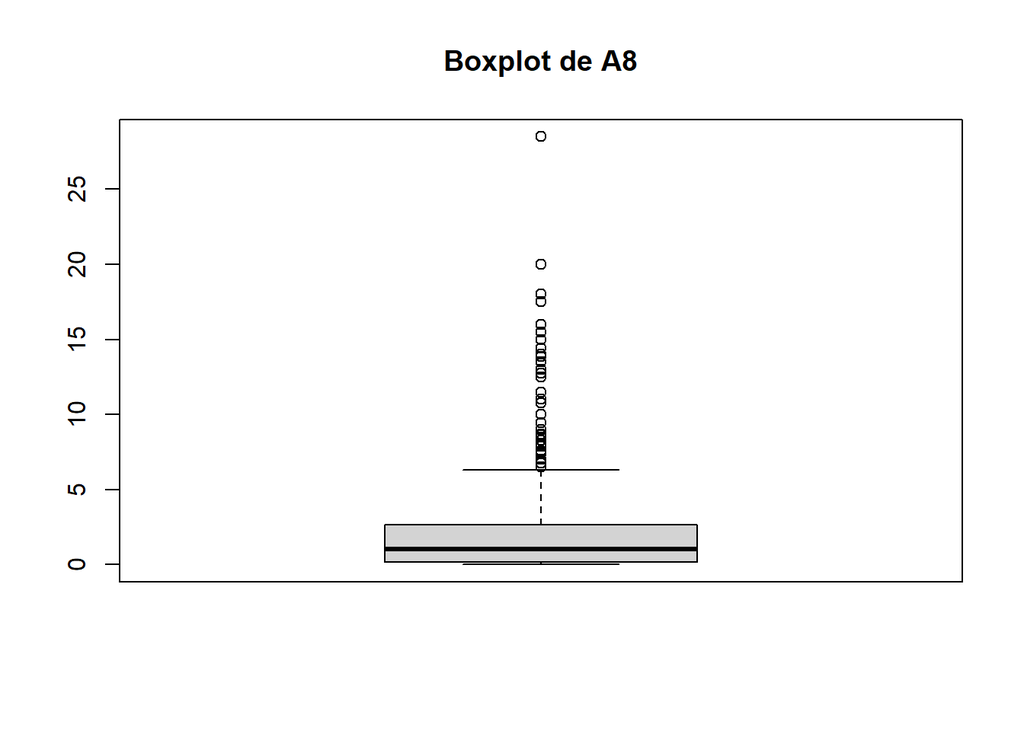

```r
boxplot(sinNA[8],names = c("A8"),main="Boxplot de A8")
```

Podemos ver como el hecho de que había muchos outliers es cierto, ya que en el diagrama vemos la cantidad de valores fuera del rango que tiene esta variable.

### A11:

```r
a11 <- (sinNA$A11)
stats11 <- boxplot.stats(a11)
atipic11 <- stats11$out
porcentajeA11 <- 100 * length(atipic11) / length(a11)

print(paste("El porcentaje de datos atípicos para A11 es =", porcentajeA11))
```

```
## [1] "El porcentaje de datos atípicos para A11 es = 12.0980091883614"
```

Si en la variable anterior pensábamos que había muchos outliers, la variable A11 presenta todavía más (más de un 12%). Viendo el histograma podremos tener una mejor visión de este hecho:

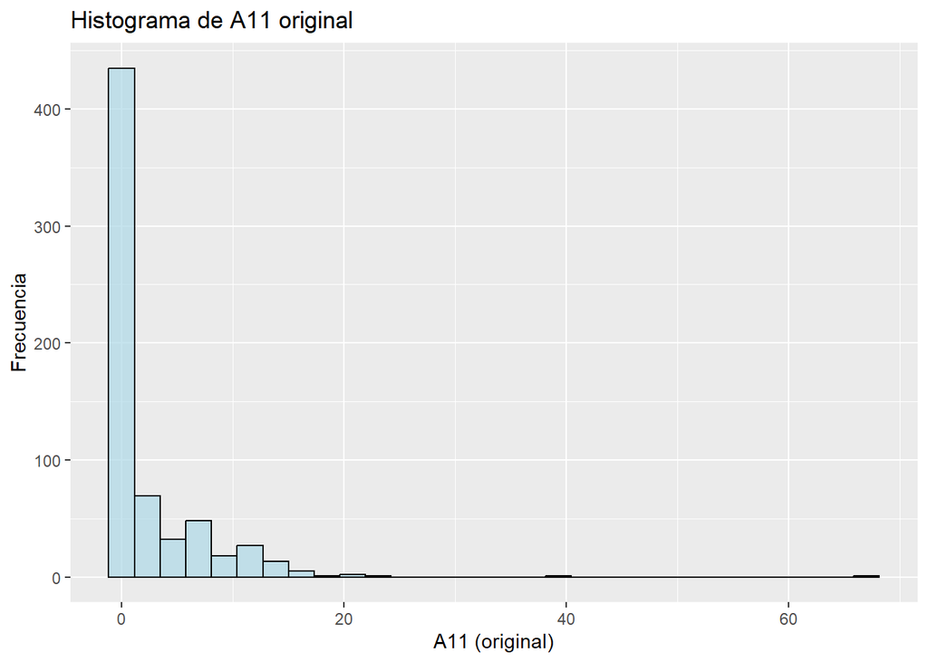

```r
ggplot(sinNA, aes(x = A11)) +
  geom_histogram(bins = 30, fill = "lightblue", color = "black", alpha = 0.7) +
  labs(title = "Histograma de A11 original", x = "A11 (original)", y = "Frecuencia")
```

Y complementándolo con el caja-bigotes, podremos ver más claramente cómo se organizan estos átipicos.

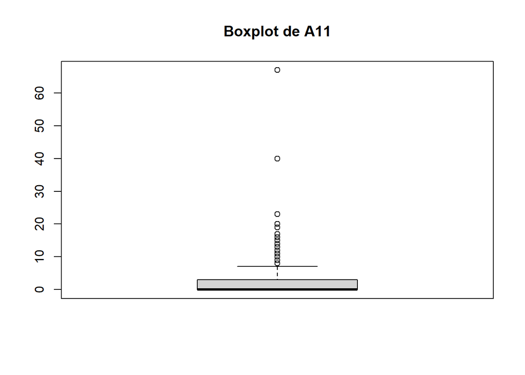

```r
boxplot(sinNA[11],names = c("A11"),main="Boxplot de A11")
```

Analizando tanto el histograma como el diagrama caja bigotes, tenemos varios valores fuera del rango y, por tanto, el valor que sale del porcentaje de outliers de la variable se demuestra con estos gráficos. En el caso del caja-bigotes, podemos ver cómo estos se encuentran, aunque fuera del rango que entendemos como datos “típicos”, la mayoría están bastante cerca de estos.

### A14:

```r
a14 <- (sinNA$A14)
stats14 <- boxplot.stats(a14)
atipic14 <- stats14$out
porcentajeA14 <- 100 * length(atipic14) / length(a14)

print(paste("El porcentaje de datos atípicos para A14 es =", porcentajeA14))
```

```
## [1] "El porcentaje de datos atípicos para A14 es = 1.68453292496172"
```

A14 presenta, como podemos ver si comparamos con el resto de variables, el menor porcentaje de datos atípicos. De todos modos, aunque no creemos que este bajo porcentaje vaya a afectar de manera negativa a los análisis, vamos a verlos con los gráficos para estudiarlos con un mayor alcance.

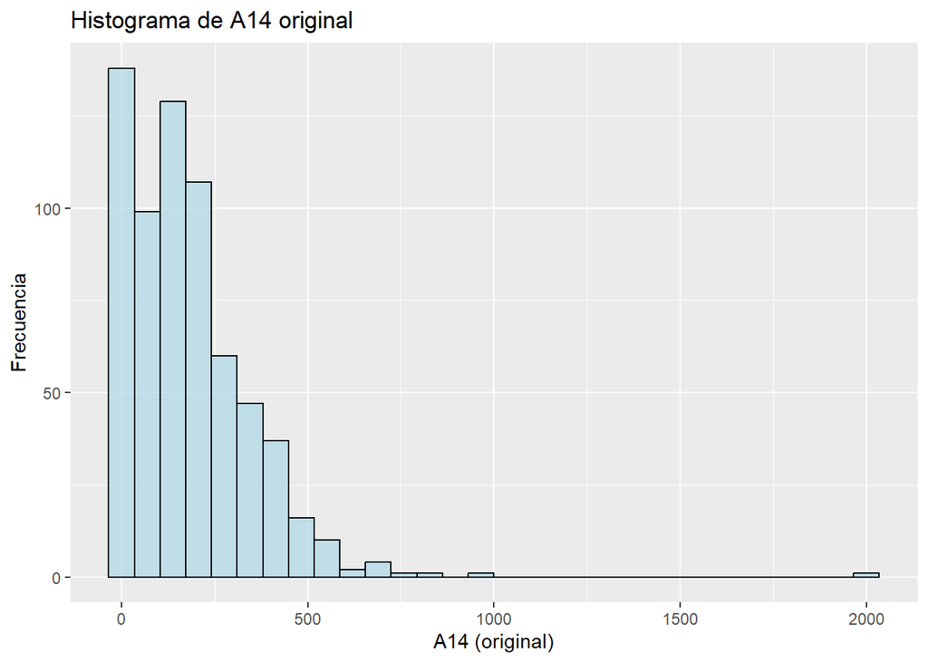

```r
ggplot(sinNA, aes(x = A14)) +
  geom_histogram(bins = 30, fill = "lightblue", color = "black", alpha = 0.7) +
  labs(title = "Histograma de A14 original", x = "A14 (original)", y = "Frecuencia")
```

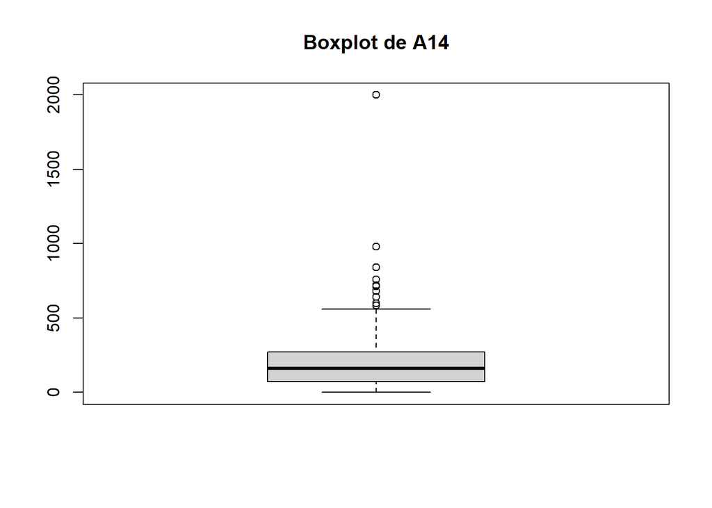

```r
boxplot(sinNA[14],names = c("A14"),main="Boxplot de A14")
```

este caso vemos claramente que el número de outliers es, realmente, muy reducido comparando con el resto de variables. Si nos fijamos en los diagramas, vemos como para representar los valores fuera de rango son necesarios un menor número de círculos. Lo que sí es cierto es que los datos típicos se encuentran, aproximadamente entre 0 y 700, y tenemos un dato que alcanzaría el valor 2000, por lo que igual sí es posible que afecte a los resultados. Sin embargo y como ya hemos comentado, no conocemos la naturaleza de los datos, por lo que es posible que simplemente sea un extremo y no aporte nada negativo.

### A15:

Como vimos en el apartado de análisis monovariable, la variable A15 tiene un porcentaje elevado (con respecto a los demás) de valores fuera de rango o atípicos.

```r
a15 <- (sinNA$A15)
stats15 <- boxplot.stats(a15)
atipic15 <- stats15$out
porcentajeA15 <- 100 * length(atipic15) / length(a15)

print(paste("El porcentaje de datos atípicos para A15 es =", porcentajeA15))
```

```
## [1] "El porcentaje de datos atípicos para A15 es = 14.854517611026"
```

Como ya hemos analizado esta variable con los gráficos en el apartado comentado, podemos pasar ya a hacer una especie de conclusión de este subapartado.

A modo de resumen, podemos clasificar las variables analizadas entre variables con baja proporción de outliers y variables con gran proporción de outliers. En el primer grupo entrarían A2, A3 y A14, mientras que en el segundo incluimos A8, A11 y A15.

Aunque se han identificado outliers en diversas variables, no se han modificado en esta fase del análisis porque pertenecen al contexto natural del problema y porque su tratamiento debe adaptarse a los algoritmos seleccionados posteriormente. Dado que caret permite normalizar, escalar y, en general, aplicar transformaciones, el manejo de los outliers se realizará durante el preprocesado, diferenciando entre variables con alta presencia de valores extremos y variables con porporciones menores. Por ello, este análisis ha sido completamente necesario para el desarrollo de la práctica.

## Eliminación de variables superfluas

Durante el proceso de preprocesado es fundamental identificar y retirar aquellas variables que no aportan información relevante al modelo. Estas variables, conocidas como variables superfluas, pueden introducir ruido, aumentar la complejidad del modelo o reducir su capacidad de generalización. Al suprimirlas del conjunto podemos obtener uno más compacto, eficiente y fácil de interpretar, teniendo en cuenta que esto no afecta a la capacidad predictiva.

A continuación detallamos los criterios aplicados para detectar y eliminar este tipo de variables en el dataset, comenzando por aquellas que presentan poca variabilidad.

### Eliminación de variables con poca varianza

Las variables con poca varianza apenas aportan información útil para los modelos de clasificación, ya que sus valores apenas cambian entre observaciones. Este tipo de variables suele tener un único valor dominante y, por tanto, no contribuye a distinguir entre clases. Para comprobar si en nuestro dataset existe alguna variable de este tipo, utilizamos la función nearZeroVar() de la librería caret sobre el conjunto sinNA:

```r
nearZeroVar(sinNA)
```

```
## integer(0)
```

Como podemos ver, la función que analiza si hay alguna variable que tenga poca varianza nos devuelve 0. Esto indica que no existe ninguna variable con suficiente falta de variabilidad como para justificar su eliminación. Por tanto, en esta fase del preprocesado no eliminamos ninguna variable por este criterio.

### Eliminación de variables correladas

Otra fuente común de información redundante en un conjunto de datos son las variables altamente correladas. Cuando dos variables presentan una alta correlación entre sí, ambas aportan prácticamente la misma información al modelo, lo que puede generar problemas como sobreajuste, mayor complejidad y un incremento innecesario del tiempo de entrenamiento.

Para evaluar este aspecto, calculamos la matriz de correlaciones de las variables numéricas del dataset sinNA y analizamos si existen pares con correlación elevada (por ejemplo, superior a 0.8). Este análisis nos permite detectar posibles redundancias y decidir si alguna de estas variables debería eliminarse.

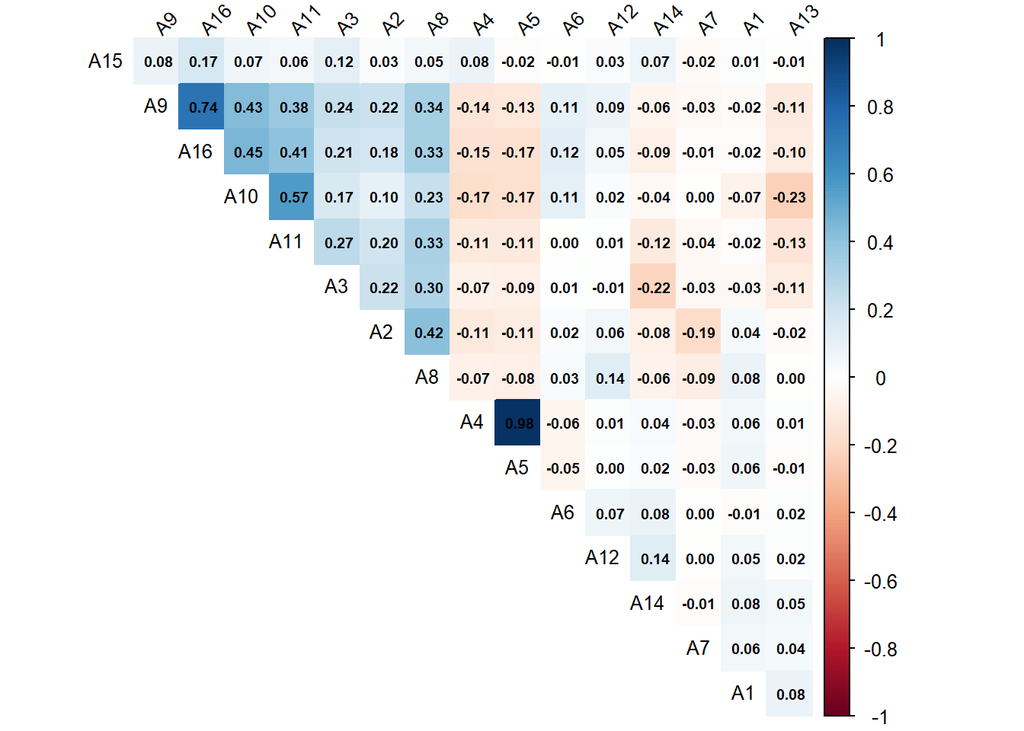

```r
sinNA2 <- sinNA
sinNA2[sapply(sinNA2, is.factor)] <- lapply(sinNA2[sapply(sinNA2, is.factor)], as.numeric)

cor_matrix <- cor(sinNA2[, 1:16], use = "complete.obs")

corrplot(cor_matrix,
         method = "color",
         type = "upper",
         order = "hclust",
         addCoef.col = "black",
         tl.col = "black",
         tl.cex = 0.8,
         number.cex = 0.6,
         tl.srt = 45,
         diag = FALSE)
```

Como podemos observar en la matriz de correlación anterior, las variables A4 y A5 están bastante correladas, ya que vemos un 0.98 (>0.8, como hemos seleccionado de límite) en la casilla que las relaciona. No obstante, vamos a analizar un poco más a fondo esta correlación:

```r
summary(sinNA$A4)
```

```
##   u   y   l   t
## 499 152   2   0
```

```r
summary(sinNA$A5)
```

```
##   g  gg   p
## 499   2 152
```

Como vemos, ambas variables tienen estructurados, en la misma proporción, sus valores: “u”, “y”, “l” y “t” (inlcuimos dicho nivel en secciones anteriores) en A4 y “g”, “gg”, “p” y “?” (eliminado al pasar de ccredit a sinNA) en A5. Así, vamos a eliminar la variable A4.

```r
sinNA$A4 <- NULL
summary(sinNA)
```

```
##  A1            A2              A3          A5            A6            A7
##  a:203   Min.   :13.75   Min.   : 0.000   g :499   c      :133   v      :381
##  b:450   1st Qu.:22.58   1st Qu.: 1.040   gg:  2   q      : 75   h      :137
##          Median :28.42   Median : 2.835   p :152   w      : 63   ff     : 54
##          Mean   :31.50   Mean   : 4.830            i      : 55   bb     : 53
##          3rd Qu.:38.25   3rd Qu.: 7.500            aa     : 52   j      :  8
##          Max.   :76.75   Max.   :28.000            ff     : 50   z      :  8
##                                                    (Other):225   (Other): 12
##        A8         A9      A10          A11         A12     A13
##  Min.   : 0.000   f:304   f:366   Min.   : 0.000   f:351   g:598
##  1st Qu.: 0.165   t:349   t:287   1st Qu.: 0.000   t:302   p:  2
##  Median : 1.000                   Median : 0.000           s: 53
##  Mean   : 2.244                   Mean   : 2.502
##  3rd Qu.: 2.625                   3rd Qu.: 3.000
##  Max.   :28.500                   Max.   :67.000
##
##       A14              A15         A16
##  Min.   :   0.0   Min.   :     0   -:357
##  1st Qu.:  73.0   1st Qu.:     0   +:296
##  Median : 160.0   Median :     5
##  Mean   : 180.4   Mean   :  1014
##  3rd Qu.: 272.0   3rd Qu.:   400
##  Max.   :2000.0   Max.   :100000
##
```

Como resultado vemos, al hacer el summary, que la variable A4 ya no aparece.

## Separación de datos en entrenamiento y testing

Una vez concluido el análisis exploratorio, procederemos a separar el dataset en conjunto de entrenamiento y conjunto de testing, ya que, como queda explicado en la introducción, necesitamos tener los dos por separado para poder obtener resultados concluyentes.

Cabe destacar que volvemos a trabajar con el conjunto de ccredit, es decir, nos olvidamos de sinNA. Esto es así porque a partir de este momento ya vamos a trabajar con el conjunto real, al cual le aplicaremos ciertas transformaciones que, como se esperaría, incluirán el tratamiento de dichos nulos.

Primero, y a modo de curiosidad, vamos a ver cuál es el porcentaje total de datos de train:

```r
credit.trainIdx <- readRDS("./credit.trainIdx.rds")
length(credit.trainIdx) / nrow(ccredit) * 100
```

```
## [1] 84.92754
```

Aquí vemos como el conjunto de entrenamiento constituye el 84.93% del conjunto de datos original.

Vamos ahora a comprobar si hay datos nulos en el conjunto de test

```r
colSums(is.na(ccredit[-credit.trainIdx, ]))
```

```
##  A1  A2  A3  A4  A5  A6  A7  A8  A9 A10 A11 A12 A13 A14 A15 A16
##   0   0   0   0   0   0   0   0   0   0   0   0   0   0   0   0
```

Podemos ver que el conjunto de test está libre de valores nulos, y por tanto, ya podemos separar ambos conjuntos.

```r
datosEntrenamiento <- ccredit[credit.trainIdx, ]
datosTest <- ccredit[-credit.trainIdx, ]
```

Hemos decidido no eliminar outliers puesto que, al no conocer la naturaleza de las variables, no podemos estar seguros de si realmente existen outliers o si son simplemente valores atípicos. Lo que sí haremos será eliminar la variable A4 puesto que, junto con A5, son equivalentes, como hemos visto anteriormente. Puesto que lo hemos hecho en el conjunto sinNA, vamos a suprimirla ahora de ccredit.

```r
ccredit$A4 <- NULL
```

Como hemos separado el conjunto de entrenamiento del de testing previamente a eliminar la variable correlada, vamos a eliminarla ahora también de dichos conjuntos:

```r
datosEntrenamiento$A4 <- NULL
datosTest$A4 <- NULL
```

## Imputación de nulos

Vamos a generar distintos datasets para diferentes métodos de imputación de datos y contrastar cuál funciona mejor en los modelos a usar. La idea es probar técnicas sencillas y más sofisticadas para ver cuál mantiene mejor la integridad y la calidad de la información original.

### Valores nulos

En el primer dataset simplemente prescindiremos de las filas con valores nulos, puesto que es el más sencillo. Este enfoque es directo y no introduce sesgo, aunque reduce el tamaño del dataset.

```r
datosEntrenamientoSinNulos <- na.omit(datosEntrenamiento)
(1 - nrow(datosEntrenamientoSinNulos)/nrow(datosEntrenamiento)) * 100
```

```
## [1] 6.313993
```

```r
write.csv(datosEntrenamientoSinNulos, file = "datosEntrenamientoSinNulos.csv", row.names = FALSE)
summary(datosEntrenamientoSinNulos)
```

```
##  A1            A2              A3          A5            A6            A7
##  a:169   Min.   :13.75   Min.   : 0.000   g :422   c      :115   v      :325
##  b:380   1st Qu.:22.67   1st Qu.: 1.040   gg:  2   q      : 62   h      :113
##          Median :28.50   Median : 3.000   p :125   w      : 52   bb     : 46
##          Mean   :31.75   Mean   : 4.782            aa     : 45   ff     : 45
##          3rd Qu.:38.33   3rd Qu.: 7.080            i      : 45   z      :  7
##          Max.   :76.75   Max.   :28.000            ff     : 41   dd     :  5
##                                                    (Other):189   (Other):  8
##        A8         A9      A10          A11         A12     A13
##  Min.   : 0.000   f:256   f:309   Min.   : 0.000   f:297   g:501
##  1st Qu.: 0.210   t:293   t:240   1st Qu.: 0.000   t:252   p:  2
##  Median : 1.000                   Median : 0.000           s: 46
##  Mean   : 2.324                   Mean   : 2.543
##  3rd Qu.: 2.750                   3rd Qu.: 3.000
##  Max.   :28.500                   Max.   :67.000
##
##       A14              A15         A16
##  Min.   :   0.0   Min.   :     0   -:299
##  1st Qu.:  80.0   1st Qu.:     0   +:250
##  Median : 160.0   Median :     5
##  Mean   : 183.5   Mean   :  1105
##  3rd Qu.: 280.0   3rd Qu.:   456
##  Max.   :2000.0   Max.   :100000
##
```

Como podemos observar, tan solo hemos perdido un 6% de los datos, lo cual es aceptable para este caso. Finalmente, guardamos el conjunto de entrenamiento limpio para poder usarlo más tarde en el entrenamiento de los modelos.

Este dataset servirá como referencia para comparar los efectos de la imputación más sofisticada.

### Mediana en numéricos y moda en categóricos

```r
datosEntrenamientoMedianaYModa <- datosEntrenamiento %>%
  mutate(across(
    where(is.factor),
    ~ replace(.x, is.na(.x), names(which.max(table(.x))))
  )) %>%
  mutate(across(
    where(is.numeric),
    ~ replace(.x, is.na(.x), median(.x, na.rm = TRUE))
  ))

write.csv(datosEntrenamientoMedianaYModa, file = "datosEntrenamientoMedianaYModa.csv", row.names = FALSE)
summary(datosEntrenamientoMedianaYModa)
```

```
##  A1            A2              A3          A5            A6            A7
##  a:176   Min.   :13.75   Min.   : 0.000   g :448   c      :128   v      :352
##  b:410   1st Qu.:22.69   1st Qu.: 1.010   gg:  2   q      : 65   h      :114
##          Median :28.54   Median : 2.875   p :136   w      : 53   bb     : 52
##          Mean   :31.75   Mean   : 4.701            i      : 49   ff     : 48
##          3rd Qu.:37.75   3rd Qu.: 7.030            aa     : 47   z      :  7
##          Max.   :80.25   Max.   :28.000            ff     : 44   dd     :  5
##                                                    (Other):200   (Other):  8
##        A8         A9      A10          A11        A12     A13
##  Min.   : 0.000   f:281   f:338   Min.   : 0.00   f:320   g:528
##  1st Qu.: 0.165   t:305   t:248   1st Qu.: 0.00   t:266   p:  8
##  Median : 1.000                   Median : 0.00           s: 50
##  Mean   : 2.294                   Mean   : 2.42
##  3rd Qu.: 2.750                   3rd Qu.: 3.00
##  Max.   :28.500                   Max.   :67.00
##
##       A14              A15         A16
##  Min.   :   0.0   Min.   :     0   -:325
##  1st Qu.:  80.0   1st Qu.:     0   +:261
##  Median : 160.0   Median :     4
##  Mean   : 187.1   Mean   :  1103
##  3rd Qu.: 280.0   3rd Qu.:   433
##  Max.   :2000.0   Max.   :100000
##
```

Este método permite conservar todas las filas, evitando pérdida de datos, y proporciona un dataset equilibrado para el entrenamiento de modelos que no toleran nulos.

### KNNImputation

En el tercer dataset utilizaremos un método más potente: KNNImputation. Este enfoque se basa en los k-vecinos más cercanos y considera todas las variables a la hora de imputar un valor. A diferencia de la media o la mediana, captura relaciones no lineales entre variables, reduce el sesgo del dataset y puede mejorar los resultados de modelos complejos como Redes Neuronales o Random Forest.

Al aplicar KNN, es necesario convertir las variables categóricas a numéricas , ya que KNN solo trabaja con valores numéricos. Esto lo haremos aplicando one hot encoding, de manera que se crean nuevos predictores, uno por nivel de cada variable categorica, conteniendo cada uno de estos valores numéricos.

Lo primero que vamos a hacer entonces es convertirlo a numéricos:

```r
dummies_model_knn <- dummyVars(A16 ~ ., data = datosEntrenamiento)
train_num <- predict(dummies_model_knn, newdata = datosEntrenamiento)
test_num  <- predict(dummies_model_knn, newdata = datosTest)
```

Y posteriormente aplicamos la KNNImputation:

```r
preProc_knn <- preProcess(train_num, method = c("knnImpute", "center", "scale"))

datosEntrenamientoKNN <- data.frame(predict(preProc_knn, train_num), A16 = datosEntrenamiento$A16)
datosTestKNN          <- data.frame(predict(preProc_knn, test_num), A16 = datosTest$A16)

summary(datosEntrenamientoKNN)
```

```
##       A1.a                A1.b                 A2                  A3
##  Min.   :-0.664410   Min.   :-1.502473   Min.   :-1.484061   Min.   :-0.9734
##  1st Qu.:-0.664410   1st Qu.:-1.502473   1st Qu.:-0.749768   1st Qu.:-0.7643
##  Median :-0.664410   Median : 0.664410   Median :-0.265989   Median :-0.3781
##  Mean   :-0.003252   Mean   : 0.003252   Mean   :-0.003009   Mean   : 0.0000
##  3rd Qu.: 1.502473   3rd Qu.: 0.664410   3rd Qu.: 0.487195   3rd Qu.: 0.4821
##  Max.   : 1.502473   Max.   : 0.664410   Max.   : 3.977960   Max.   : 4.8237
##       A5.g               A5.gg                 A5.p
##  Min.   :-1.788121   Min.   :-0.0587728   Min.   :-0.552972
##  1st Qu.: 0.558282   1st Qu.:-0.0587728   1st Qu.:-0.552972
##  Median : 0.558282   Median :-0.0587728   Median :-0.552972
##  Mean   :-0.003093   Mean   :-0.0006018   Mean   : 0.003192
##  3rd Qu.: 0.558282   3rd Qu.:-0.0587728   3rd Qu.:-0.552972
##  Max.   : 0.558282   Max.   :16.9853385   Max.   : 1.805291
##      A6.aa                A6.c               A6.cc
##  Min.   :-0.297532   Min.   :-0.509289   Min.   :-0.257736
##  1st Qu.:-0.297532   1st Qu.:-0.509289   1st Qu.:-0.257736
##  Median :-0.297532   Median :-0.509289   Median :-0.257736
##  Mean   :-0.002076   Mean   : 0.003135   Mean   : 0.001681
##  3rd Qu.:-0.297532   3rd Qu.:-0.509289   3rd Qu.:-0.257736
##  Max.   : 3.355153   Max.   : 1.960120   Max.   : 3.873207
##       A6.d                A6.e               A6.ff              A6.i
##  Min.   :-0.221373   Min.   :-0.198925   Min.   :-0.2871   Min.   :-0.304372
##  1st Qu.:-0.221373   1st Qu.:-0.198925   1st Qu.:-0.2871   1st Qu.:-0.304372
##  Median :-0.221373   Median :-0.198925   Median :-0.2871   Median :-0.304372
##  Mean   :-0.001785   Mean   : 0.002287   Mean   : 0.0033   Mean   :-0.002228
##  3rd Qu.:-0.221373   3rd Qu.:-0.198925   3rd Qu.:-0.2871   3rd Qu.:-0.304372
##  Max.   : 4.509442   Max.   : 5.018322   Max.   : 3.4774   Max.   : 3.279761
##       A6.j                A6.k                 A6.m
##  Min.   :-0.102419   Min.   :-0.2799440   Min.   :-0.2380717
##  1st Qu.:-0.102419   1st Qu.:-0.2799440   1st Qu.:-0.2380717
##  Median :-0.102419   Median :-0.2799440   Median :-0.2380717
##  Mean   :-0.001573   Mean   :-0.0003617   Mean   : 0.0008807
##  3rd Qu.:-0.102419   3rd Qu.:-0.2799440   3rd Qu.:-0.2380717
##  Max.   : 9.746883   Max.   : 3.5659527   Max.   : 4.1931347
##       A6.q               A6.r                A6.w                A6.x
##  Min.   :-0.35600   Min.   :-0.058926   Min.   :-0.317757   Min.   :-0.250013
##  1st Qu.:-0.35600   1st Qu.:-0.058926   1st Qu.:-0.317757   1st Qu.:-0.250013
##  Median :-0.35600   Median :-0.058926   Median :-0.317757   Median :-0.250013
##  Mean   :-0.00331   Mean   :-0.000905   Mean   : 0.001023   Mean   :-0.002392
```

[output cut: 36 more lines]

```
##  Max.   :12.8652   Max.   : 0.911   Max.   : 1.096   Max.   : 0.3312
##      A13.p             A13.s              A14                 A15
##  Min.   :-0.1175   Min.   :-0.3052   Min.   :-1.058668   Min.   :-0.1962
##  1st Qu.:-0.1175   1st Qu.:-0.3052   1st Qu.:-0.607484   1st Qu.:-0.1962
##  Median :-0.1175   Median :-0.3052   Median :-0.156300   Median :-0.1955
##  Mean   : 0.0000   Mean   : 0.0000   Mean   :-0.004207   Mean   : 0.0000
##  3rd Qu.:-0.1175   3rd Qu.:-0.3052   3rd Qu.: 0.520475   3rd Qu.:-0.1192
##  Max.   : 8.4927   Max.   : 3.2713   Max.   :10.220926   Max.   :17.5934
##  A16
##  -:325
##  +:261
##
##
##
##
```

```r
write.csv(datosEntrenamientoKNN, file = "datosEntrenamientoKNN.csv", row.names = FALSE)
```

## Transformación de variables:

Antes de entrenar cualquier modelo, es fundamental asegurar que los datos estén en una escala adecuada y que los valores extremos no distorsionen el aprendizaje. La transformación de variables permite que los modelos que dependen de la magnitud de los datos, como SVM, Redes Neuronales o Random Forest, funcionen de manera más eficiente y estable.

En este proyecto hemos decidido diferenciar las variables según la proporción de valores atípicos (outliers) que presentan:

- Gran proporción de outliers: A8, A11 y A15
- Baja proporción de outliers: A2, A3 y A14

Para las variables con muchos outliers aplicaremos una normalización robusta, centrando los valores en la mediana y escalándolos según el rango intercuartílico (RIC). Esto reduce el impacto de valores extremos y permite que la mayoría de los algoritmos trabajen de forma más consistente.

Para las variables con pocos outliers utilizaremos una normalización Min-Max, que ajusta los valores al rango 0–1. Esta transformación mantiene la forma de la distribución y facilita comparaciones entre variables sin alterar su estructura relativa.

Cada uno de los tres datasets generados previamente (SinNulos, MedianaYModa y KNNImputation) será tratado por separado para garantizar que las transformaciones respeten las características originales de cada conjunto de datos. Este paso asegura que los modelos aprendan patrones reales y no se vean sesgados por diferencias de escala o valores extremos.

#### Variables con muchos valores fuera de rango (outliers)

En primer lugar, aplicamos una normalización robusta con el objetivo de reducir el efecto que producen los valores extremos en aquellas variables que presentan un porcentaje elevado de outliers, identificadas en el análisis previo.

El ajuste de escala permite que todas las variables queden expresadas en un mismo rango, facilitando así la interpretación de su distribución y su comparación sin que las diferencias en la magnitud original distorsionen los resultados. Además, este procedimiento evita posibles problemas con algoritmos de modelado que no son invariantes al cambio de escala.

Llevamos a cabo el proceso de normalización. Lo haremos por separado para cada uno de los datasets obtenidos con anterioridad, comenzando con “sinNulos”:

```r
datosEntrenamientoSinNulos.Normalizados=datosEntrenamientoSinNulos
preprocSinNulos <- preProcess(datosEntrenamientoSinNulos.Normalizados[, c("A8", "A11", "A15")], method = c("center", "scale"),
                      center = apply(datosEntrenamientoSinNulos[, c("A8", "A11", "A15")], 2, median),
                      scale = apply(datosEntrenamientoSinNulos[, c("A8", "A11", "A15")], 2, IQR))

datosEntrenamientoSinNulos.Normalizados[, c("A8", "A11", "A15")] <- predict(preprocSinNulos, datosEntrenamientoSinNulos.Normalizados[, c("A8", "A11", "A15")])
head(datosEntrenamientoSinNulos.Normalizados[, c("A8", "A11", "A15")])
```

```
##            A8        A11         A15
## 1 -0.30533252 -0.2995335 -0.19395332
## 2  0.20377605  0.6712096 -0.09562749
## 3 -0.23422797 -0.4936821 -0.04927389
## 4  0.40571297  0.4770610 -0.19342657
## 5 -0.17450015 -0.4936821 -0.19395332
## 6  0.05019023 -0.4936821 -0.19395332
```

A continuación continuamos normalizando el dataset obtenido al emitir los nulos mediante la inserción de la mediana o la moda según la naturaleza de las variables:

```r
datosEntrenamientoMedianaYModa.Normalizados=datosEntrenamientoMedianaYModa
preprocMedianaYModa <- preProcess(datosEntrenamientoMedianaYModa.Normalizados[, c("A8", "A11", "A15")], method = c("center", "scale"),
                      center = apply(datosEntrenamientoMedianaYModa[, c("A8", "A11", "A15")], 2, median),
                      scale = apply(datosEntrenamientoMedianaYModa[, c("A8", "A11", "A15")], 2, IQR))

datosEntrenamientoMedianaYModa.Normalizados[, c("A8", "A11", "A15")] <- predict(preprocMedianaYModa, datosEntrenamientoMedianaYModa.Normalizados[, c("A8", "A11", "A15")])
head(datosEntrenamientoMedianaYModa.Normalizados[, c("A8", "A11", "A15")])
```

```
##            A8        A11         A15
## 1 -0.30000978 -0.2828422 -0.19624818
## 2  0.21440760  0.7132246 -0.09662639
## 3 -0.22816378 -0.4820555 -0.04966184
## 4  0.41845025  0.5140112 -0.19571449
## 5 -0.16781314 -0.4820555 -0.19624818
## 6  0.05922023 -0.4820555 -0.19624818
```

Por último, normalizamos el conjunto de datos relacionado con KNNImputation:

```r
datosEntrenamientoKNN.Normalizados=datosEntrenamientoKNN
preprocKNN <- preProcess(datosEntrenamientoKNN.Normalizados[, c("A8", "A11", "A15")], method = c("center", "scale"),
                      center = apply(datosEntrenamientoKNN[, c("A8", "A11", "A15")], 2, median),
                      scale = apply(datosEntrenamientoKNN[, c("A8", "A11", "A15")], 2, IQR))

datosEntrenamientoKNN.Normalizados[, c("A8", "A11", "A15")] <- predict(preprocKNN, datosEntrenamientoKNN.Normalizados[, c("A8", "A11", "A15")])
head(datosEntrenamientoKNN.Normalizados[, c("A8", "A11", "A15")])
```

```
##            A8        A11         A15
## 1 -0.30000978 -0.2828422 -0.19624818
## 2  0.21440760  0.7132246 -0.09662639
## 3 -0.22816378 -0.4820555 -0.04966184
## 4  0.41845025  0.5140112 -0.19571449
## 5 -0.16781314 -0.4820555 -0.19624818
## 6  0.05922023 -0.4820555 -0.19624818
```

Al observar los resultados, podemos verificar que la normalización se ha aplicado correctamente. Como vemos, no hay gran diferencia en los valores de cada uno de los datasets, ya que la imputación de nulos se ha realizado a un número de NAs bastante bajo, por lo que la diferencia entre los 3 procesos es prácticamente imperceptible.

La aparición de valores negativos es completamente esperable, ya que este tipo de normalización sitúa el centro en la mediana y utiliza el RIC como medida de escala. Por ello, los valores negativos indican que se encuentran por debajo de la mediana, mientras que los positivos se sitúan por encima.

#### Variables con pocos valores fuera de rango (outliers)

Tras el análisis previo, observamos que las variables A2, A3 y A14 presentan valores atípicos, aunque en menor proporción que otras variables.

Para garantizar que todos los valores estén en la misma escala y facilitar el entrenamiento de los modelos, aplicaremos una normalización Min-Max. Esta transformación ajusta los valores para que queden en el rango de 0 a 1, manteniendo la forma general de la distribución y permitiendo comparaciones coherentes entre las variables.

Guardar Min y max de entrenamiento:

```r
variables_log <- c("A2", "A3", "A14")

minsSinNulos <- sapply(datosEntrenamientoSinNulos.Normalizados[, variables_log], min)
maxsSinNulos <- sapply(datosEntrenamientoSinNulos.Normalizados[, variables_log], max)

minsMedianaYModa <- sapply(datosEntrenamientoMedianaYModa.Normalizados[, variables_log], min)
maxsMedianaYModa <- sapply(datosEntrenamientoMedianaYModa.Normalizados[, variables_log], max)

minsKNN <- sapply(datosEntrenamientoKNN.Normalizados[, variables_log], min)
maxsKNN <- sapply(datosEntrenamientoKNN.Normalizados[, variables_log], max)
```

Definimos la función de normalización Min-Max:

```r
normalizar <- function(x, minv, maxv) (x - minv) / (maxv - minv)
```

Volvemos a tratar los 3 conjuntos por separado:

##### 1. SinNulos

```r
for (v in variables_log) {
  datosEntrenamientoSinNulos.Normalizados[[v]] <- normalizar(datosEntrenamientoSinNulos.Normalizados[[v]], minsSinNulos[v], maxsSinNulos[v])
}
```

##### 2. MedianaYModa

```r
for (v in variables_log) {
  datosEntrenamientoMedianaYModa.Normalizados[[v]] <- normalizar(datosEntrenamientoMedianaYModa.Normalizados[[v]], minsMedianaYModa[v], maxsMedianaYModa[v])
}
```

##### 3. KNN

```r
for (v in variables_log) {
  datosEntrenamientoKNN.Normalizados[[v]] <- normalizar(datosEntrenamientoKNN.Normalizados[[v]], minsKNN[v], maxsKNN[v])
}
```

Finalmente, verificamos que los datos se encuentren correctamente normalizados:

##### 1. SinNulos

```r
summary(datosEntrenamientoSinNulos.Normalizados[, c("A2", "A3", "A14")])
```

```
##        A2               A3               A14
##  Min.   :0.0000   Min.   :0.00000   Min.   :0.00000
##  1st Qu.:0.1416   1st Qu.:0.03714   1st Qu.:0.04000
##  Median :0.2341   Median :0.10714   Median :0.08000
##  Mean   :0.2858   Mean   :0.17078   Mean   :0.09176
##  3rd Qu.:0.3902   3rd Qu.:0.25286   3rd Qu.:0.14000
##  Max.   :1.0000   Max.   :1.00000   Max.   :1.00000
```

##### 2. MedianaYModa

```r
summary(datosEntrenamientoMedianaYModa.Normalizados[, c("A2", "A3", "A14")])
```

```
##        A2               A3               A14
##  Min.   :0.0000   Min.   :0.00000   Min.   :0.00000
##  1st Qu.:0.1344   1st Qu.:0.03607   1st Qu.:0.04000
##  Median :0.2224   Median :0.10268   Median :0.08000
##  Mean   :0.2707   Mean   :0.16791   Mean   :0.09355
##  3rd Qu.:0.3609   3rd Qu.:0.25107   3rd Qu.:0.14000
##  Max.   :1.0000   Max.   :1.00000   Max.   :1.00000
```

##### 3. KNN

```r
summary(datosEntrenamientoKNN.Normalizados[, c("A2", "A3", "A14")])
```

```
##        A2               A3               A14
##  Min.   :0.0000   Min.   :0.00000   Min.   :0.00000
##  1st Qu.:0.1344   1st Qu.:0.03607   1st Qu.:0.04000
##  Median :0.2230   Median :0.10268   Median :0.08000
##  Mean   :0.2712   Mean   :0.16791   Mean   :0.09348
##  3rd Qu.:0.3609   3rd Qu.:0.25107   3rd Qu.:0.14000
##  Max.   :1.0000   Max.   :1.00000   Max.   :1.00000
```

Los valores están ahora todos entre 0 y 1, lo que garantiza que los modelos que dependen de la escala de las variables funcionen correctamente, mientras que la forma general de la distribución se mantiene.

En relación a la de KNN, se observa que los valores normalizados resultan muy similares a los valores previos a la normalización. Esto no indica un fallo en el proceso, sino que es un comportamiento esperado cuando se utiliza KNNImputation. Este método únicamente modifica las observaciones donde existían valores faltantes, manteniendo prácticamente intactas las distribuciones originales del resto de datos. Como consecuencia, los rangos y escalas de las variables apenas cambian y, por tanto, las distribuciones antes y después de normalizar son visualmente muy parecidas. Aun así, la normalización sigue siendo necesaria, especialmente en algoritmos que dependen de distancias, ya que garantiza que todas las variables tengan una contribución equilibrada en los modelos posteriores.

Vamos a observarlo en gráficas comparativas para los 3 datasets:

##### 1. SinNulos

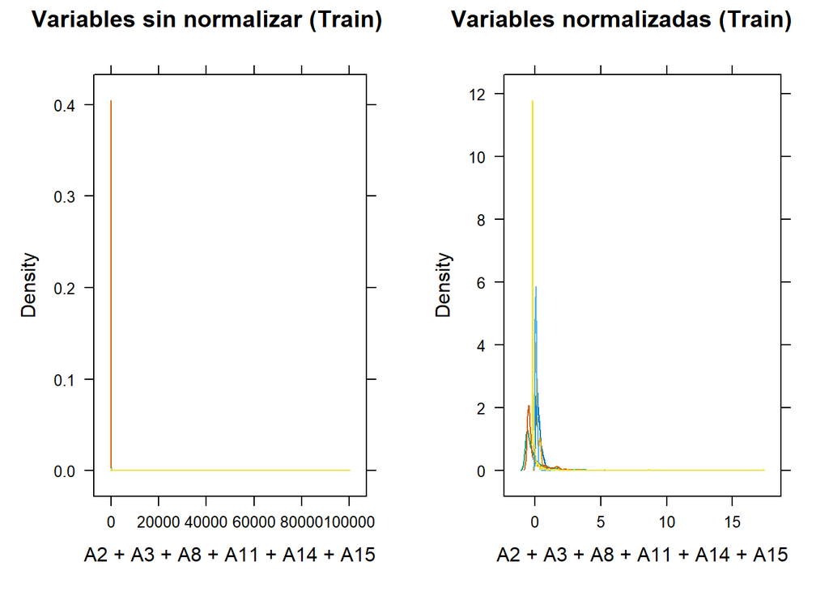

```r
numeric_cols <- c("A2","A3","A8","A11","A14","A15")

d1 <- densityplot(
  as.formula(paste("~", paste(numeric_cols, collapse = " + "))),
  data = datosEntrenamientoSinNulos,
  main = "Variables sin normalizar (Train)",
  plot.points = FALSE
)

d2 <- densityplot(
  as.formula(paste("~", paste(numeric_cols, collapse = " + "))),
  data = datosEntrenamientoSinNulos.Normalizados,
  main = "Variables normalizadas (Train)",
  plot.points = FALSE
)

print(d1, position = c(0, 0, 0.5, 1), more = TRUE)
print(d2, position = c(0.5, 0, 1, 1))
```

##### 2. MedianaYModa

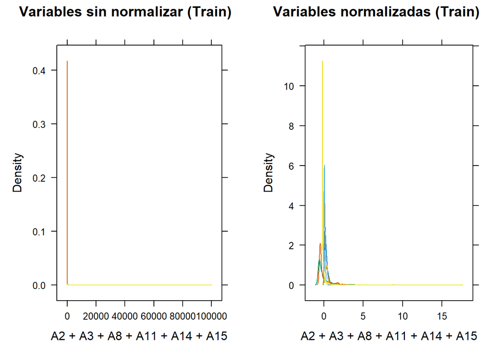

```r
numeric_cols <- c("A2","A3","A8","A11","A14","A15")

d1 <- densityplot(
  as.formula(paste("~", paste(numeric_cols, collapse = " + "))),
  data = datosEntrenamientoMedianaYModa,
  main = "Variables sin normalizar (Train)",
  plot.points = FALSE
)

d2 <- densityplot(
  as.formula(paste("~", paste(numeric_cols, collapse = " + "))),
  data = datosEntrenamientoMedianaYModa.Normalizados,
  main = "Variables normalizadas (Train)",
  plot.points = FALSE
)

print(d1, position = c(0, 0, 0.5, 1), more = TRUE)
print(d2, position = c(0.5, 0, 1, 1))
```

##### 3. KNN

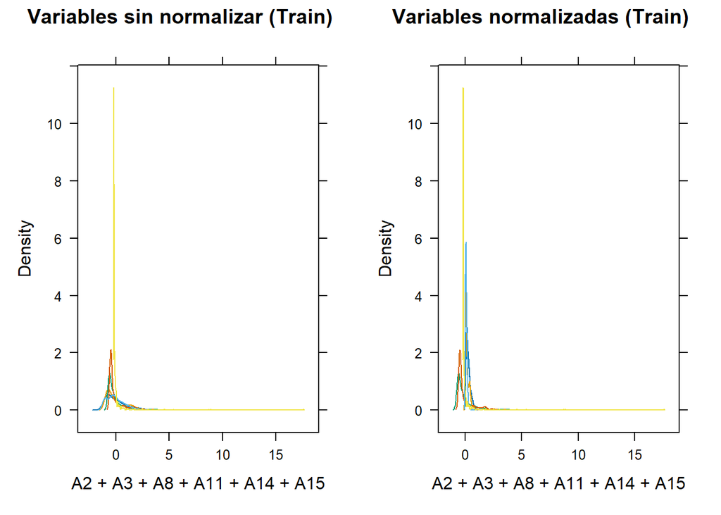

```r
numeric_cols <- c("A2","A3","A8","A11","A14","A15")

d1 <- densityplot(
  as.formula(paste("~", paste(numeric_cols, collapse = " + "))),
  data = datosEntrenamientoKNN,
  main = "Variables sin normalizar (Train)",
  plot.points = FALSE
)

d2 <- densityplot(
  as.formula(paste("~", paste(numeric_cols, collapse = " + "))),
  data = datosEntrenamientoKNN.Normalizados,
  main = "Variables normalizadas (Train)",
  plot.points = FALSE
)

print(d1, position = c(0, 0, 0.5, 1), more = TRUE)
print(d2, position = c(0.5, 0, 1, 1))
```

En el dataset KNN, las gráficas antes y después de normalizar son muy similares debido a que las imputaciones apenas modifican los valores originales.

### Aplicar los cambios y transformaciones a los datos de Test

Lo primero que haremos será copiar los datasets de test correspondientes, es decir, asignamos “datosTest” a los 3 conjuntos que usaremos para cada una de las transformaciones:

```r
datosTest_SinNulos.Normalizados <- datosTest
datosTest_MedianaYModa.Normalizados <- datosTest
datosTest_KNN.Normalizados <- datosTestKNN
```

Del mismo modo que en los datos de entrenamiento, aquí diferenciaremos entre pocos y muchos outliers, por lo que vamos a tratar distinto a las variables de cada tipo. Comenzamos con las de menor porcentaje de atípicos:

```r
for (v in variables_log) {

datosTest_SinNulos.Normalizados[[v]] <- normalizar(datosTest_SinNulos.Normalizados[[v]], minsSinNulos[v], maxsSinNulos[v])
datosTest_MedianaYModa.Normalizados[[v]] <- normalizar(datosTest_MedianaYModa.Normalizados[[v]], minsMedianaYModa[v], maxsMedianaYModa[v])
datosTest_KNN.Normalizados[[v]] <- normalizar(datosTest_KNN.Normalizados[[v]], minsKNN[v], maxsKNN[v])
}
```

Continuamos ahora con las de más outliers:

```r
variables_robust <- c("A8", "A11", "A15")

datosTest_SinNulos.Normalizados[, variables_robust] <- predict(preprocSinNulos, datosTest_SinNulos.Normalizados[, variables_robust])
datosTest_MedianaYModa.Normalizados[, variables_robust] <- predict(preprocMedianaYModa, datosTest_MedianaYModa.Normalizados[, variables_robust])
datosTest_KNN.Normalizados[, variables_robust] <- predict(preprocKNN, datosTest_KNN.Normalizados[, variables_robust])
```

Ahora comprobamos que los cambios se han realizado correctamente:

```r
summary(datosTest_SinNulos.Normalizados[, c(variables_log, variables_robust)])
```

```
##        A2                A3               A14                A8
##  Min.   :0.03175   Min.   :0.00000   Min.   :0.00000   Min.   :-0.66086
##  1st Qu.:0.13393   1st Qu.:0.02982   1st Qu.:0.02513   1st Qu.:-0.62530
##  Median :0.22952   Median :0.07661   Median :0.06750   Median :-0.40559
##  Mean   :0.26091   Mean   :0.18149   Mean   :0.08182   Mean   :-0.14150
##  3rd Qu.:0.36115   3rd Qu.:0.32366   3rd Qu.:0.12000   3rd Qu.: 0.05019
##  Max.   :0.87175   Max.   :0.94054   Max.   :0.38000   Max.   : 3.28545
##       A11                A15
##  Min.   :-0.49368   Min.   :-0.1940
##  1st Qu.:-0.49368   1st Qu.:-0.1940
##  Median :-0.49368   Median :-0.1925
##  Mean   :-0.04938   Mean   :-0.1002
##  3rd Qu.: 0.08876   3rd Qu.:-0.1365
##  Max.   : 2.80684   Max.   : 1.3601
```

```r
summary(datosTest_MedianaYModa.Normalizados[, c(variables_log, variables_robust)])
```

```
##        A2                A3               A14                A8
##  Min.   :0.03008   Min.   :0.00000   Min.   :0.00000   Min.   :-0.65924
##  1st Qu.:0.12688   1st Qu.:0.02982   1st Qu.:0.02513   1st Qu.:-0.62332
##  Median :0.21744   Median :0.07661   Median :0.06750   Median :-0.40131
##  Mean   :0.24717   Mean   :0.18149   Mean   :0.08182   Mean   :-0.13447
##  3rd Qu.:0.34214   3rd Qu.:0.32366   3rd Qu.:0.12000   3rd Qu.: 0.05922
##  Max.   :0.82586   Max.   :0.94054   Max.   :0.38000   Max.   : 3.32821
##       A11                A15
##  Min.   :-0.48206   Min.   :-0.1962
##  1st Qu.:-0.48206   1st Qu.:-0.1962
##  Median :-0.48206   Median :-0.1948
##  Mean   :-0.02616   Mean   :-0.1012
##  3rd Qu.: 0.11558   3rd Qu.:-0.1380
##  Max.   : 2.90457   Max.   : 1.3783
```

```r
summary(datosTest_KNN.Normalizados[, c(variables_log, variables_robust)])
```

```
##        A2                A3               A14                A8
##  Min.   :0.03008   Min.   :0.00000   Min.   :0.00000   Min.   :-0.65924
##  1st Qu.:0.12688   1st Qu.:0.02982   1st Qu.:0.02513   1st Qu.:-0.62332
##  Median :0.21744   Median :0.07661   Median :0.06750   Median :-0.40131
##  Mean   :0.24717   Mean   :0.18149   Mean   :0.08182   Mean   :-0.13447
##  3rd Qu.:0.34214   3rd Qu.:0.32366   3rd Qu.:0.12000   3rd Qu.: 0.05922
##  Max.   :0.82586   Max.   :0.94054   Max.   :0.38000   Max.   : 3.32821
##       A11                A15
##  Min.   :-0.48206   Min.   :-0.1962
##  1st Qu.:-0.48206   1st Qu.:-0.1962
##  Median :-0.48206   Median :-0.1948
##  Mean   :-0.02616   Mean   :-0.1012
##  3rd Qu.: 0.11558   3rd Qu.:-0.1380
##  Max.   : 2.90457   Max.   : 1.3783
```

# Sección 2: Entrenamiento de los potenciales modelos a usar

Al no tener muchos datos utilizaremos Validación cruzada con 5 pliegues, esto significa que cada conjunto de datos se divide en 5 partes (folds), entrenando con 4 y validando con 1, rotando hasta que cada fold haya sido usado como validación.

Repetimos el proceso 2 veces para reducir la variabilidad y obtener métricas más confiables. Esto tiene ciertas ventajas como poder aprovechar al máximo los datos disponibles. Además reduce la dependencia de la partición específica de train/test. Proporciona estimaciones más estables de métricas como Accuracy y Kappa.

Para ello, primero vamos a estableces una semilla para asegurar la replicabilidad

```r
set.seed(777)
```

Y ya procedemos a declarar el proceso de validación cruzada con 5 pliegues:

```r
creditEntrenamiento5x2 <- trainControl(
method = "repeatedcv",
number = 5,
repeats = 2,
savePredictions = "final",
classProbs = FALSE
)
```

## Support Vector Machines (SVM)

Hemos decidido entrenar un model Support Vector Machines(svm) ya que funciona especialmente bien con problemas de clasificación binaria como es el nuestro, trazando un hiperplano que distingue entre las dos clases, ademas utilizaremos una implementación de este algoritmo que no es lineal (svmRadial), ya que no tenemos certeza de que nuestra clase se comporte de esa manera.

Antes que nada hay que realizar One Hot Encoding ya que este modelo no trabaja con variables categóricas directamente.

```r
# 1. Convertir A16 a factor (asegurado)
datosEntrenamientoSinNulos.Normalizados$A16 <- as.factor(datosEntrenamientoSinNulos.Normalizados$A16)
datosEntrenamientoMedianaYModa.Normalizados$A16 <- as.factor(datosEntrenamientoMedianaYModa.Normalizados$A16)
datosEntrenamientoKNN.Normalizados$A16 <- as.factor(datosEntrenamientoKNN.Normalizados$A16)

# 2. Crear dummyVars solo con las variables predictoras
dummyObj_SinNulos <- dummyVars(~ ., data = datosEntrenamientoSinNulos.Normalizados[, setdiff(names(datosEntrenamientoSinNulos.Normalizados), "A16")], fullRank = TRUE)
dummySinNulos <- as.data.frame(predict(dummyObj_SinNulos, newdata = datosEntrenamientoSinNulos.Normalizados))
dummySinNulos$A16 <- datosEntrenamientoSinNulos.Normalizados$A16

dummyObj_MedianaYModa <- dummyVars(~ ., data = datosEntrenamientoMedianaYModa.Normalizados[, setdiff(names(datosEntrenamientoMedianaYModa.Normalizados), "A16")], fullRank = TRUE)
dummyMedianaYModa <- as.data.frame(predict(dummyObj_MedianaYModa, newdata = datosEntrenamientoMedianaYModa.Normalizados))
dummyMedianaYModa$A16 <- datosEntrenamientoMedianaYModa.Normalizados$A16

dummyObj_KNN <- dummyVars(~ ., data = datosEntrenamientoKNN.Normalizados[, setdiff(names(datosEntrenamientoKNN.Normalizados), "A16")], fullRank = TRUE)
dummyKNN <- as.data.frame(predict(dummyObj_KNN, newdata = datosEntrenamientoKNN.Normalizados))
dummyKNN$A16 <- datosEntrenamientoKNN.Normalizados$A16
```

Separaremos el conjunto entre las variables de entrada (A1-A15) y variables de salida (A16). Lo hacemos ahora, ya que al hacer el one hot encoding, las variables categóricas cambian.

```r
datosVarEntrenamientoSalida = "A16"
datosVarEntrenamientoEntrada = setdiff(names(dummySinNulos), datosVarEntrenamientoSalida)
```

Vamos a probar el modelo con los distintos dataset y vamos a comprobar cual funciona mejor. Además, establecemos una nueva semilla antes del entrenamiento (set.seed(1234)) para asegurar que esta fase sea totalmente reproducible e independiente de los procesos previos realizados en el documento.

```r
set.seed(1234)

creditEntrenamiento5x2SVM_SinNulos<-train(dummySinNulos[datosVarEntrenamientoEntrada],
                                          dummySinNulos[[datosVarEntrenamientoSalida]],
                                          method='svmRadial',
                                          trControl=creditEntrenamiento5x2)
creditEntrenamiento5x2SVM_SinNulos
```

```
## Support Vector Machines with Radial Basis Function Kernel
##
## 549 samples
##  35 predictor
##   2 classes: '-', '+'
##
## No pre-processing
## Resampling: Cross-Validated (5 fold, repeated 2 times)
## Summary of sample sizes: 439, 440, 439, 439, 439, 439, ...
## Resampling results across tuning parameters:
##
##   C     Accuracy   Kappa
##   0.25  0.8551376  0.7109084
##   0.50  0.8551460  0.7120617
##   1.00  0.8533111  0.7082083
##
## Tuning parameter 'sigma' was held constant at a value of 0.02309502
## Accuracy was used to select the optimal model using the largest value.
## The final values used for the model were sigma = 0.02309502 and C = 0.5.
```

```r
creditEntrenamiento5x2SVM_MedianaYModa<-train(dummyMedianaYModa[datosVarEntrenamientoEntrada],
                                              dummyMedianaYModa[[datosVarEntrenamientoSalida]],
                                              method='svmRadial',
                                              trControl=creditEntrenamiento5x2)
creditEntrenamiento5x2SVM_MedianaYModa
```

```
## Support Vector Machines with Radial Basis Function Kernel
##
## 586 samples
##  35 predictor
##   2 classes: '-', '+'
##
## No pre-processing
## Resampling: Cross-Validated (5 fold, repeated 2 times)
## Summary of sample sizes: 469, 469, 468, 469, 469, 468, ...
## Resampling results across tuning parameters:
##
##   C     Accuracy   Kappa
##   0.25  0.8361872  0.6708361
##   0.50  0.8438505  0.6888696
##   1.00  0.8429886  0.6868867
##
## Tuning parameter 'sigma' was held constant at a value of 0.02440315
## Accuracy was used to select the optimal model using the largest value.
## The final values used for the model were sigma = 0.02440315 and C = 0.5.
```

```r
#KNN crea sus propias variables por lo que las variables de entrada para este modelo serán distintas
datosVarEntrenamientoEntradaKNN = setdiff(names(dummyKNN), datosVarEntrenamientoSalida)
dummyKNN[[datosVarEntrenamientoSalida]] <- as.factor(dummyKNN[[datosVarEntrenamientoSalida]])
creditEntrenamiento5x2SVM_KNN<-train(dummyKNN[datosVarEntrenamientoEntradaKNN],
                                     dummyKNN[[datosVarEntrenamientoSalida]],
                                     method='svmRadial', trControl=creditEntrenamiento5x2)
creditEntrenamiento5x2SVM_KNN
```

```
## Support Vector Machines with Radial Basis Function Kernel
##
## 586 samples
##  43 predictor
##   2 classes: '-', '+'
##
## No pre-processing
## Resampling: Cross-Validated (5 fold, repeated 2 times)
## Summary of sample sizes: 469, 469, 468, 469, 469, 469, ...
## Resampling results across tuning parameters:
##
##   C     Accuracy   Kappa
##   0.25  0.8455237  0.6923507
##   0.50  0.8421194  0.6861368
##   1.00  0.8378604  0.6768616
##
## Tuning parameter 'sigma' was held constant at a value of 0.0188875
## Accuracy was used to select the optimal model using the largest value.
## The final values used for the model were sigma = 0.0188875 and C = 0.25.
```

Cabe destacar que en el caso de KNN, el proceso de imputación genera un conjunto de variables ligeramente diferente al de los otros dos datasets. Por ello, es necesario volver a identificar las variables de entrada específicas para este caso. Además, aseguramos que la variable de salida sea de tipo factor antes de entrenar el modelo SVM, garantizando así un funcionamiento correcto del algoritmo.

## Random Forest (RF)

Random Forest es un algoritmo basado en la combinación de múltiples árboles de decisión. Cada árbol predice una clase, y la predicción final se obtiene mediante votación de mayoría. Este método reduce el sobreajuste y suele funcionar muy bien en problemas de clasificación binaria.

Al igual que con SVM, es necesario aplicar One-Hot Encoding a las variables categóricas para que Random Forest pueda trabajar correctamente.

### Entrenamiento de Random Forest

Vamos a entrenar un modelo Random Forest para cada uno de los tres datasets generados previamente: `SinNulos`, `MedianaYModa` y `KNN`. Utilizaremos validación cruzada 5x2 para evaluar el rendimiento del modelo en cada caso.

Primero vamos a tratar de nuevo las variables de entrada y de salida, asegurándonos de que esta última sea de tipo factor en los 3 datasets.

```r
set.seed(1234)

datosVarEntrenamientoSalida <- "A16"

datosEntrenamientoSinNulos.Normalizados[[datosVarEntrenamientoSalida]] <-
  as.factor(datosEntrenamientoSinNulos.Normalizados[[datosVarEntrenamientoSalida]])

datosEntrenamientoMedianaYModa.Normalizados[[datosVarEntrenamientoSalida]] <-
  as.factor(datosEntrenamientoMedianaYModa.Normalizados[[datosVarEntrenamientoSalida]])

datosEntrenamientoKNN.Normalizados[[datosVarEntrenamientoSalida]] <-
  as.factor(datosEntrenamientoKNN.Normalizados[[datosVarEntrenamientoSalida]])
datosEntrenamientoKNN.Normalizados$A16 <- as.factor(datosEntrenamientoKNN.Normalizados$A16)

datosVarEntrenamientoEntrada_SinNulos <- setdiff(names(datosEntrenamientoSinNulos.Normalizados), datosVarEntrenamientoSalida)
datosVarEntrenamientoEntrada_MedianaYModa <- setdiff(names(datosEntrenamientoMedianaYModa.Normalizados), datosVarEntrenamientoSalida)
datosVarEntrenamientoEntrada_KNN <- setdiff(names(datosEntrenamientoKNN.Normalizados), datosVarEntrenamientoSalida)
```

Ahora ya pasamos a entrenar el modelo de random forest con cada uno de los 3 datasets obtenidos:

```r
rf_SinNulos <- train(
  datosEntrenamientoSinNulos.Normalizados[datosVarEntrenamientoEntrada_SinNulos],
  datosEntrenamientoSinNulos.Normalizados[[datosVarEntrenamientoSalida]],
  method = "rf",
  trControl = creditEntrenamiento5x2
)

rf_MedianaYModa <- train(
  datosEntrenamientoMedianaYModa.Normalizados[datosVarEntrenamientoEntrada_MedianaYModa],
  datosEntrenamientoMedianaYModa.Normalizados[[datosVarEntrenamientoSalida]],
  method = "rf",
  trControl = creditEntrenamiento5x2
)

rf_KNN <- train(
  datosEntrenamientoKNN.Normalizados[datosVarEntrenamientoEntrada_KNN],
  datosEntrenamientoKNN.Normalizados[[datosVarEntrenamientoSalida]],
  method = "rf",
  trControl = creditEntrenamiento5x2
)
```

Por último, mostramos los resultados obtenidos:

```r
rf_SinNulos
```

```
## Random Forest
##
## 549 samples
##  14 predictor
##   2 classes: '-', '+'
##
## No pre-processing
## Resampling: Cross-Validated (5 fold, repeated 2 times)
## Summary of sample sizes: 439, 440, 439, 439, 439, 439, ...
## Resampling results across tuning parameters:
##
##   mtry  Accuracy   Kappa
##    2    0.8687823  0.7360719
##    8    0.8624187  0.7246883
##   14    0.8606088  0.7207483
##
## Accuracy was used to select the optimal model using the largest value.
## The final value used for the model was mtry = 2.
```

```r
rf_MedianaYModa
```

```
## Random Forest
##
## 586 samples
##  14 predictor
##   2 classes: '-', '+'
##
## No pre-processing
## Resampling: Cross-Validated (5 fold, repeated 2 times)
## Summary of sample sizes: 469, 469, 469, 468, 469, 469, ...
## Resampling results across tuning parameters:
##
##   mtry  Accuracy   Kappa
##    2    0.8617775  0.7193904
##    8    0.8506881  0.6991957
##   14    0.8472838  0.6917519
##
## Accuracy was used to select the optimal model using the largest value.
## The final value used for the model was mtry = 2.
```

```r
rf_KNN
```

```
## Random Forest
##
## 586 samples
##  43 predictor
##   2 classes: '-', '+'
##
## No pre-processing
## Resampling: Cross-Validated (5 fold, repeated 2 times)
## Summary of sample sizes: 469, 469, 469, 468, 469, 469, ...
## Resampling results across tuning parameters:
##
##   mtry  Accuracy   Kappa
##    2    0.8617920  0.7187613
##   22    0.8515935  0.7010628
##   43    0.8507461  0.6994101
##
## Accuracy was used to select the optimal model using the largest value.
## The final value used for the model was mtry = 2.
```

### Interpretación de resultados y comparación entre datasets

Los modelos Random Forest entrenados sobre los tres datasets (SinNulos, MedianaYModa y KNN) muestran un rendimiento muy similar, con accuracies alrededor del 86–87% y valores de Kappa en torno a 0.70–0.75. Estos valores indican que el modelo clasifica correctamente la mayoría de las instancias y que existe una buena concordancia entre las predicciones y la clase real.

Respecto a la comparación entre datasets, las diferencias son pequeñas:

1. SinNulos y MedianaYModa obtienen resultados muy similares, mostrando que ambos métodos de imputación funcionan bien con Random Forest.
2. KNN también alcanza un rendimiento prácticamente idéntico, lo que indica que el algoritmo es robusto a las distintas estrategias de imputación.

En general, Random Forest mantiene un comportamiento estable independientemente del método usado para tratar los valores ausentes, sin que un dataset destaque claramente sobre los demás. Esto sugiere que el modelo no es especialmente sensible a la técnica de imputación aplicada.

## Redes neuronales artificiales (ANN):

Las Redes Neuronales son modelos predictivos inspirados en el funcionamiento del sistema neuronal biológico. Su estructura está formada por unidades de procesamiento (neuronas) organizadas en capas: una capa de entrada, una o varias capas ocultas y una capa de salida. Cada neurona aplica una transformación a sus entradas mediante un conjunto de pesos que se ajustan a lo largo del entrenamiento mediante el algoritmo de retropropagación del error (backpropagation).

El objetivo principal de este modelo es aprender representaciones intermedias capaces de capturar relaciones no lineales entre las variables predictoras y la variable de salida. En este trabajo se utiliza el modelo nnet proporcionado por el paquete caret, que implementa un perceptrón multicapa de una única capa oculta.

Para el experimento se entrenaron tres redes neuronales, una por cada conjunto de datos derivado del preprocesamiento.

El objetivo es analizar si el método de imputación de datos influye en el rendimiento de la red neuronal y determinar cuál de los tres procesos produce un dataset más adecuado para este modelo.

Lo primero que haremos es la conversión de la variable objetivo A16 a factor para asegurar que el modelo de red neuronal la trate correctamente como variable categórica.

```r
dummySinNulos$A16 <- as.factor(dummySinNulos$A16)
dummyMedianaYModa$A16 <- as.factor(dummyMedianaYModa$A16)
dummyKNN$A16 <- as.factor(dummyKNN$A16)
```

Así ya podemos entrenar el modelo para cada uno de los datasets.

Cabe destacar que El parámetro tuneLength = 5 sirve para indicar que se probarán diferentes combinaciones de neuronas en la capa oculta (size) y valores de regularización (decay). Además, La validación cruzada 5x2, definida previamente en creditEntrenamiento5x2, asegura una evaluación robusta del rendimiento del modelo.

```r
nnet_SinNulos <- train(
  A16 ~ .,
  data = dummySinNulos,
  method = "nnet",
  trControl = creditEntrenamiento5x2,
  tuneLength = 5,
  trace = FALSE
)

nnet_MedianaYModa <- train(
  A16 ~ .,
  data = dummyMedianaYModa,
  method = "nnet",
  trControl = creditEntrenamiento5x2,
  tuneLength = 5,
  trace = FALSE
)

nnet_KNN <- train(
  A16 ~ .,
  data = dummyKNN,
  method = "nnet",
  trControl = creditEntrenamiento5x2,
  tuneLength = 5,
  trace = FALSE
)
```

Y por último, mostramos los resultados:

```r
nnet_SinNulos
```

```
## Neural Network
##
## 549 samples
##  35 predictor
##   2 classes: '-', '+'
##
## No pre-processing
## Resampling: Cross-Validated (5 fold, repeated 2 times)
## Summary of sample sizes: 440, 439, 439, 439, 439, 439, ...
## Resampling results across tuning parameters:
##
##   size  decay  Accuracy   Kappa
##   1     0e+00  0.8451960  0.6894155
##   1     1e-04  0.8433278  0.6854494
##   1     1e-03  0.8333194  0.6656243
```

[output cut: 25 more lines]

```r
nnet_MedianaYModa
```

```
## Neural Network
##
## 586 samples
##  35 predictor
##   2 classes: '-', '+'
##
## No pre-processing
## Resampling: Cross-Validated (5 fold, repeated 2 times)
## Summary of sample sizes: 469, 469, 468, 469, 469, 469, ...
## Resampling results across tuning parameters:
##
##   size  decay  Accuracy   Kappa
##   1     0e+00  0.8395770  0.6764072
##   1     1e-04  0.8413081  0.6786355
##   1     1e-03  0.8429813  0.6826622
```

[output cut: 25 more lines]

```r
nnet_KNN
```

```
## Neural Network
##
## 586 samples
##  43 predictor
##   2 classes: '-', '+'
##
## No pre-processing
## Resampling: Cross-Validated (5 fold, repeated 2 times)
## Summary of sample sizes: 469, 469, 469, 469, 468, 469, ...
## Resampling results across tuning parameters:
##
##   size  decay  Accuracy   Kappa
##   1     0e+00  0.8217080  0.6386601
##   1     1e-04  0.8438433  0.6839711
##   1     1e-03  0.8370636  0.6703730
```

[output cut: 25 more lines]

```r
nnet_SinNulos$bestTune
```

```
##    size decay
## 10    3   0.1
```

```r
nnet_MedianaYModa$bestTune
```

```
##   size decay
## 5    1   0.1
```

```r
nnet_KNN$bestTune
```

```
##   size decay
## 2    1 1e-04
```

## MODELO LDA:

En este apartado hemos decidido utilizar LDA como modelo adicional por dos motivos principales. En primer lugar, LDA funciona especialmente bien en problemas con una dimensionalidad moderada, como es nuestro caso, ya que presenta una baja tendencia al sobreajuste cuando el número de predictores no es demasiado elevado. En segundo lugar, se trata de un algoritmo computacionalmente muy eficiente, con gran rapidez computacional, lo que lo hace adecuado para datasets de tamaño medio como este, con 690 observaciones.

La validación cruzada 5×2 permite obtener una estimación estable del rendimiento para cada conjunto. Tras el entrenamiento, se observa que el mejor resultado lo ofrecía el dataset sinNulos con un accuracy del 86,3%, motivo por el cual este fue seleccionado como conjunto final para el modelo LDA.

```r
# Semilla para replicabilidad

set.seed(777)

# Entrenar modelo LDA con validación cruzada 5x2

LDA_SinNulos <- train(
A16 ~ .,
data = dummySinNulos,
method = "lda",
trControl = creditEntrenamiento5x2,
preProcess = NULL
)

LDA_MedianaYMedia <- train(
A16 ~ .,
data = dummyMedianaYModa,
method = "lda",
trControl = creditEntrenamiento5x2,
preProcess = NULL
)

LDA_KNN <- train(
A16 ~ .,
data = dummyKNN,
method = "lda",
trControl = creditEntrenamiento5x2,
preProcess = NULL
)

LDA_SinNulos
```

```
## Linear Discriminant Analysis
##
## 549 samples
##  35 predictor
##   2 classes: '-', '+'
##
## No pre-processing
## Resampling: Cross-Validated (5 fold, repeated 2 times)
## Summary of sample sizes: 439, 439, 440, 439, 439, 439, ...
## Resampling results:
##
##   Accuracy   Kappa
##   0.8633862  0.727971
```

```r
LDA_MedianaYMedia
```

```
## Linear Discriminant Analysis
##
## 586 samples
##  35 predictor
##   2 classes: '-', '+'
##
## No pre-processing
## Resampling: Cross-Validated (5 fold, repeated 2 times)
## Summary of sample sizes: 468, 469, 469, 469, 469, 469, ...
## Resampling results:
##
##   Accuracy   Kappa
##   0.8593003  0.7201046
```

```r
LDA_KNN
```

```
## Linear Discriminant Analysis
##
## 586 samples
##  43 predictor
##   2 classes: '-', '+'
##
## No pre-processing
## Resampling: Cross-Validated (5 fold, repeated 2 times)
## Summary of sample sizes: 469, 468, 469, 469, 469, 469, ...
## Resampling results:
##
##   Accuracy   Kappa
##   0.8475783  0.6969516
```

```r
LDA_SinNulos$bestTune
```

```
##   parameter
## 1      none
```

```r
LDA_MedianaYMedia$bestTune
```

```
##   parameter
## 1      none
```

```r
LDA_KNN$bestTune
```

```
##   parameter
## 1      none
```

En resumen, el modelo LDA entrenado demuestra ser una herramienta eficiente para la clasificación binaria, con métricas de rendimiento sólidas. Su implementación es directa, la interpretación de los resultados es clara y los resultados coinciden con los patrones observados en otros modelos, mostrando que el preprocesamiento de los datos y la correcta definición de factores son esenciales para obtener resultados confiables y reproducibles. La combinación de validación cruzada y preprocesamiento garantiza que las métricas de Accuracy y Kappa sean robustas y representativas del desempeño real del modelo.

# Sección 3: Comparar modelos

Para seleccionar el modelo final, se realiza una comparación sistemática de todos los modelos entrenados con sus distintos preprocesamientos. Se evalúan métricas clave como Accuracy y Kappa, lo que permite no solo identificar el modelo con mejor rendimiento promedio, sino también comprobar su consistencia y robustez frente a distintos conjuntos de datos. Este análisis es fundamental para decidir qué modelo utilizará el dataset final y asegurará generalización a datos nuevos.

```r
# Función para extraer métricas de los modelos
extraer_metrics <- function(modelo, nombre_modelo, preproc){
  res <- modelo$results
  mejor <- res[which.max(res$Accuracy),]
  data.frame(
    Modelo = nombre_modelo,
    Preprocesamiento = preproc,
    Accuracy = mejor$Accuracy,
    Kappa = mejor$Kappa,
    MejorTune = paste(names(mejor)[grepl("size|decay|mtry|C|sigma", names(mejor))],
                      mejor[grepl("size|decay|mtry|C|sigma", names(mejor))], sep="=", collapse = ", ")
  )
}

# Extraer métricas de todos los modelos
svm_results <- bind_rows(
  extraer_metrics(creditEntrenamiento5x2SVM_SinNulos, "SVM Radial", "SinNulos"),
  extraer_metrics(creditEntrenamiento5x2SVM_MedianaYModa, "SVM Radial", "MedianaYModa"),
  extraer_metrics(creditEntrenamiento5x2SVM_KNN, "SVM Radial", "KNN")
)

rf_results <- bind_rows(
  extraer_metrics(rf_SinNulos, "Random Forest", "SinNulos"),
  extraer_metrics(rf_MedianaYModa, "Random Forest", "MedianaYModa"),
  extraer_metrics(rf_KNN, "Random Forest", "KNN")
)

nnet_results <- bind_rows(
  extraer_metrics(nnet_SinNulos, "Red Neuronal", "SinNulos"),
  extraer_metrics(nnet_MedianaYModa, "Red Neuronal", "MedianaYModa"),
  extraer_metrics(nnet_KNN, "Red Neuronal", "KNN")
)

lda_results <- data.frame(
  extraer_metrics(LDA_SinNulos, "LDA", "SinNulos"),
  extraer_metrics(LDA_MedianaYMedia, "LDA", "MedianaYModa"),
  extraer_metrics(LDA_KNN, "LDA", "KNN")
)

# Combinar todos los resultados
comparacion_modelos <- bind_rows(rf_results, nnet_results, svm_results, lda_results)
comparacion_modelos <- comparacion_modelos %>% arrange(desc(Accuracy))

# Mostrar tabla comparativa
print(comparacion_modelos)
```

```
##           Modelo Preprocesamiento  Accuracy     Kappa
## 1  Random Forest         SinNulos 0.8687823 0.7360719
## 2            LDA         SinNulos 0.8633862 0.7279710
## 3  Random Forest              KNN 0.8617920 0.7187613
## 4  Random Forest     MedianaYModa 0.8617775 0.7193904
## 5     SVM Radial         SinNulos 0.8551460 0.7120617
## 6   Red Neuronal         SinNulos 0.8543203 0.7066568
## 7   Red Neuronal     MedianaYModa 0.8464291 0.6901313
## 8     SVM Radial              KNN 0.8455237 0.6923507
## 9     SVM Radial     MedianaYModa 0.8438505 0.6888696
## 10  Red Neuronal              KNN 0.8438433 0.6839711
##                           MejorTune Modelo.1 Preprocesamiento.1 Accuracy.1
## 1                            mtry=2     <NA>               <NA>         NA
## 2                                        LDA       MedianaYModa  0.8593003
## 3                            mtry=2     <NA>               <NA>         NA
```

[output cut: 29 more lines]

```r
# Selección del mejor modelo y entrenamiento final
mtry_optimo <- comparacion_modelos %>%
  filter(Modelo == "Random Forest", Preprocesamiento == "SinNulos") %>%
  pull(MejorTune)

set.seed(1234)
modelo_final_rf <- train(
  dummySinNulos[datosVarEntrenamientoEntrada],
  dummySinNulos[[datosVarEntrenamientoSalida]],
  method = "rf",
  trControl = trainControl(method = "repeatedcv", number = 5, repeats = 2),
  tuneGrid = data.frame(mtry = 18)
)

# Resumen del modelo final
print(modelo_final_rf)
```

```
## Random Forest
##
## 549 samples
##  35 predictor
##   2 classes: '-', '+'
##
## No pre-processing
## Resampling: Cross-Validated (5 fold, repeated 2 times)
## Summary of sample sizes: 439, 440, 439, 439, 439, 439, ...
## Resampling results:
##
##   Accuracy   Kappa
##   0.8615179  0.7223813
##
## Tuning parameter 'mtry' was held constant at a value of 18
```

Para visualizar de manera más intuitiva la comparación de modelos, se emplean gráficas de resamples, incluyendo boxplots, density plots y dotplots que muestran la distribución de Accuracy y Kappa de cada modelo.

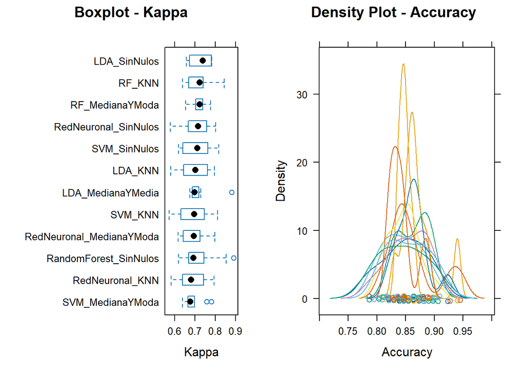

```r
# Preparar lista de modelos para la función resamples

lista_modelos <- list(
RandomForest_SinNulos = modelo_final_rf,
RedNeuronal_SinNulos = nnet_SinNulos,
RedNeuronal_MedianaYModa = nnet_MedianaYModa,
RedNeuronal_KNN = nnet_KNN,
SVM_SinNulos = creditEntrenamiento5x2SVM_SinNulos,
SVM_MedianaYModa = creditEntrenamiento5x2SVM_MedianaYModa,
SVM_KNN = creditEntrenamiento5x2SVM_KNN,
LDA_SinNulos = LDA_SinNulos,
LDA_MedianaYMedia = LDA_MedianaYMedia,
LDA_KNN = LDA_KNN,
RF_MedianaYModa = rf_MedianaYModa,
RF_KNN = rf_KNN
)

# Crear objeto resamples para comparar métricas

resultados <- resamples(lista_modelos)

# Boxplot de Kappa

bw_plot <- bwplot(resultados, metric = "Kappa", main = "Boxplot - Kappa")

# Density plot de Accuracy y Kappa

density_plot_acc <- densityplot(resultados, metric = "Accuracy", main = "Density Plot - Accuracy")
density_plot_kappa <- densityplot(resultados, metric = "Kappa", main = "Density Plot - Kappa")

# Dotplot de Accuracy

dot_plot_acc <- dotplot(resultados, metric = "Accuracy", main = "Dotplot - Accuracy")

# Mostrar gráficas combinadas

grid.arrange(bw_plot, density_plot_acc, ncol = 2)
```

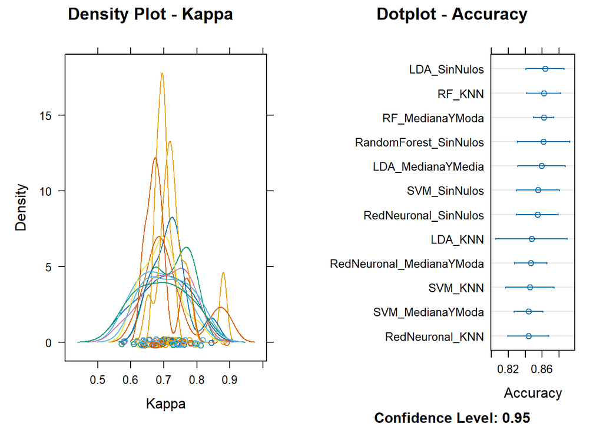

```r
grid.arrange(density_plot_kappa, dot_plot_acc, ncol = 2)
```